# Laboratorio 3 – Aprendizaje de máquina

## Recomendación de planes personalizados para SmartAlpes

### Integrantes:

1. Juan Sebastian Rodriguez Torres - 202214617 - js.rodriguezt1@uniandes.edu.co
2. Luis Felipe Sales Galviz - 202211531 - l.sales@uniandes.edu.co

Aqui desarrollaremos un sistema de recomendación de planes de entrenamiento y nutrición para los usuarios de SmartAlpes. Como el número de usuarios aumenta se ha recopilado información sobre los clientes para crear modelos que generen recomendaciones personalizadas de manera consistente.

Vamos a desarrollar y comparar los 4 modelos de clasificación que permitan predecir:

- Un plan de entrenamiento recomendado (Uno creado con Regresión logística y otro con árbol de decisión).
- Un plan de nutrición recomendado. (Uno creado con Regresión logística y otro con árbol de decisión).

# 1. Carga de datos

Los datos utilizados en este laboratorio contienen información demográfica, física y de estilo de vida de los usuarios, junto con las recomendaciones de planes de entrenamiento y nutrición que ya se habian asignado a los usuarios.

Ahora procedemos a cargar el dataset principal y visualizar sus primeras filas.

```python
import pandas as pd
import numpy as np
import matplotlib.pyplot as plt
import seaborn as sns

from sklearn.model_selection import train_test_split, GridSearchCV, StratifiedKFold, KFold
from sklearn.pipeline import Pipeline
from sklearn.compose import ColumnTransformer
from sklearn.preprocessing import StandardScaler, OneHotEncoder
from sklearn.impute import SimpleImputer
from sklearn.linear_model import LogisticRegression
from sklearn.tree import DecisionTreeClassifier, plot_tree, export_text
from sklearn.metrics import classification_report, confusion_matrix, precision_score, recall_score, f1_score, ConfusionMatrixDisplay, accuracy_score

sns.set(style="whitegrid")
plt.rcParams["figure.figsize"] = (8,5)

df_real = pd.read_csv("./data/Datos_Laboratorio3.csv", sep=";", encoding="latin1")
df = df_real.copy()
df.head(8)
```

|  | Edad | Gnereo | Peso | Altura | BMI | Objetivo | Condicion_salud | Nivel_Actividad | Nivel_experiencia | Dieta_preferida | ... | Fumador | Cigarrillos_dia | Alcohol | Alcohol_semana | Score_micronutrientes | Ingesta_proteinas | Pasos_dia | Ingesta_agua | Plan_entrenamiento | Plan_nutrición |
| --- | --- | --- | --- | --- | --- | --- | --- | --- | --- | --- | --- | --- | --- | --- | --- | --- | --- | --- | --- | --- | --- |
| 0 | 60 | Masculino | 73.7 | 1.61 | 28.43 | Resistencia | Hipertension | Bajo | Avanzado | Vegano | ... | 0 | 0.0 | 0 | 0.0 | 0.92 | 182.1 | 16485 | 2.49 | Medio | Sin plan |
| 1 | 17 | Femenino | 121.0 | 1.97 | 31.18 | Resistencia | Enfermedad corazon | Moderado | Principiante | Vegetariano | ... | 0 | 0.0 | 0 | 0.0 | 0.76 | 167.7 | 14256 | 2.04 | Ninguno | Sin plan |
| 2 | 43 | Masculino | 110.0 | 1.52 | 47.61 | General | Ninguno | Bajo | Principiante | No-Vegetariano | ... | 0 | 0.0 | 0 | 0.0 | 0.34 | 104.9 | 3050 | 2.53 | Bajo | Basico |
| 3 | 49 | Otro | 73.6 | 1.96 | 19.16 | General | Ninguno | Moderado | Principiante | No-Vegetariano | ... | 0 | 0.0 | 0 | 0.0 | 0.71 | 59.5 | 2264 | 3.36 | Ninguno | Sin plan |
| 4 | 53 | Femenino | 80.8 | 1.76 | 26.08 | Resistencia | Hipertension | Alto | Principiante | Pescetariano | ... | 1 | 8.7 | 0 | 0.0 | 0.98 | 51.1 | 12774 | 1.90 | Medio | Sin plan |
| 5 | 32 | Masculino | 134.8 | 1.61 | 52.00 | Perdida grasa | Ninguno | Moderado | Avanzado | Pescetariano | ... | 1 | 6.1 | 0 | 0.0 | 0.22 | 152.4 | 7525 | 1.34 | Medio | Balanceado |
| 6 | 34 | Femenino | 101.9 | 2.05 | 24.25 | General | Hipertension | Alto | Intermedio | Pescetariano | ... | 0 | 0.0 | 0 | 0.0 | 0.51 | 205.6 | 11066 | 1.52 | Bajo | Sin plan |
| 7 | 57 | Femenino | 120.6 | 1.72 | 40.77 | Ganancia muscular | Lesion | Moderado | Intermedio | No-Vegetariano | ... | 0 | 0.0 | 1 | 16.6 | 0.79 | 54.9 | 10772 | 2.23 | Bajo | Especializado |

8 rows × 26 columns

# 2. Exploración y análisis de los datos

En esta sección se realiza una exploración del dataset para comprender su estructura y las características de los datos, y tambien identificar posibles problemas de calidad en los datos que deban ser modificados para un correcto uso.

Queremos identificar:

- Número de filas y columnas.
- Tipos de variables presentes.
- Distribución general de los datos.
- Valores faltantes.
- Registros duplicados.
- Distribución de variables numéricas.
- Distribución de variables categóricas.
- Presencia de valores atípicos (outliers).
- Balance de clases en las variables objetivo.

```python
print("\n\n◉ INFORMACION DEL DATAFRAME (NO NULOS Y TIPOS DE DATOS):\n")
df.info()
```

```
◉ INFORMACION DEL DATAFRAME (NO NULOS Y TIPOS DE DATOS):

<class 'pandas.core.frame.DataFrame'>
RangeIndex: 9698 entries, 0 to 9697
Data columns (total 26 columns):
 #   Column                   Non-Null Count  Dtype
---  ------                   --------------  -----
 0   Edad                     9698 non-null   int64
 1   Gnereo                   9698 non-null   object
 2   Peso                     9687 non-null   float64
 3   Altura                   9698 non-null   float64
 4   BMI                      9698 non-null   float64
 5   Objetivo                 9698 non-null   object
 6   Condicion_salud          9698 non-null   object
 7   Nivel_Actividad          9698 non-null   object
```

[output cut: 20 more lines]

```python
print("\n\n◉ DESCRIPCIÓN ESTADÍSTICA - VARIABLES NUMÉRICAS:\n")
df.describe()
```

```
◉ DESCRIPCIÓN ESTADÍSTICA - VARIABLES NUMÉRICAS:
```

|  | Edad | Peso | Altura | BMI | Horas_sueño | Cantidad_equipo | Tiempo_disponible | Tiene_alergia | Problemas_digestivos | Fumador | Cigarrillos_dia | Alcohol | Alcohol_semana | Score_micronutrientes | Ingesta_proteinas | Pasos_dia | Ingesta_agua |
| --- | --- | --- | --- | --- | --- | --- | --- | --- | --- | --- | --- | --- | --- | --- | --- | --- | --- |
| count | 9698.000000 | 9687.000000 | 9698.000000 | 9698.000000 | 9698.000000 | 9698.000000 | 9698.000000 | 9698.000000 | 9698.000000 | 9698.000000 | 9698.000000 | 9698.000000 | 9698.000000 | 9698.000000 | 9698.000000 | 9698.000000 | 9698.000000 |
| mean | 45.112601 | 92.622515 | 1.775047 | 30.131391 | 7.004382 | 2.988039 | 67.194061 | 0.201588 | 0.153846 | 0.227366 | 2.172252 | 0.285317 | 3.778841 | 0.500115 | 129.997360 | 9765.936482 | 2.748532 |
| std | 17.641045 | 27.383913 | 0.158754 | 10.605675 | 1.449454 | 2.018493 | 30.839475 | 0.401207 | 0.360820 | 0.419153 | 4.624756 | 0.451588 | 7.023263 | 0.289062 | 51.981874 | 4762.152079 | 1.015342 |
| min | 15.000000 | 45.000000 | 1.500000 | 10.930000 | 0.000000 | 0.000000 | 15.000000 | 0.000000 | 0.000000 | 0.000000 | 0.000000 | 0.000000 | 0.000000 | 0.000000 | 40.000000 | 200.000000 | 1.000000 |
| 25% | 30.000000 | 68.800000 | 1.640000 | 21.620000 | 5.800000 | 1.000000 | 40.000000 | 0.000000 | 0.000000 | 0.000000 | 0.000000 | 0.000000 | 0.000000 | 0.250000 | 85.000000 | 5608.250000 | 1.860000 |
| 50% | 45.000000 | 92.600000 | 1.780000 | 29.190000 | 7.000000 | 3.000000 | 67.000000 | 0.000000 | 0.000000 | 0.000000 | 0.000000 | 0.000000 | 0.000000 | 0.500000 | 129.950000 | 9718.000000 | 2.760000 |
| 75% | 61.000000 | 116.500000 | 1.910000 | 37.060000 | 8.200000 | 5.000000 | 94.000000 | 0.000000 | 0.000000 | 0.000000 | 0.000000 | 1.000000 | 4.300000 | 0.750000 | 175.200000 | 13953.000000 | 3.620000 |
| max | 75.000000 | 140.000000 | 2.050000 | 62.090000 | 23.000000 | 6.000000 | 120.000000 | 1.000000 | 1.000000 | 1.000000 | 18.000000 | 1.000000 | 25.000000 | 1.000000 | 220.000000 | 17996.000000 | 4.500000 |

```python
print("◉ (EXPLORACIÓN) QUÉ PASA SI ELIMINAMOS TODOS LOS REGISTROS CON DATOS NULOS:")
print("Tamaño antes:", df.shape)
df_prueba1 = df.dropna()
print("Tamaño después:", df_prueba1.shape)
```

```
◉ (EXPLORACIÓN) QUÉ PASA SI ELIMINAMOS TODOS LOS REGISTROS CON DATOS NULOS:
Tamaño antes: (9698, 26)
Tamaño después: (9687, 26)
```

```python
total_duplicados = df.duplicated().sum()
print("\n◉ CANTIDAD DE REGISTROS DUPLICADOS: " + str(total_duplicados))
```

```
◉ CANTIDAD DE REGISTROS DUPLICADOS: 0
```

```
◉ HEATMAP PARA VER CORRELACIÓN ENTRE VARIABLES:
```

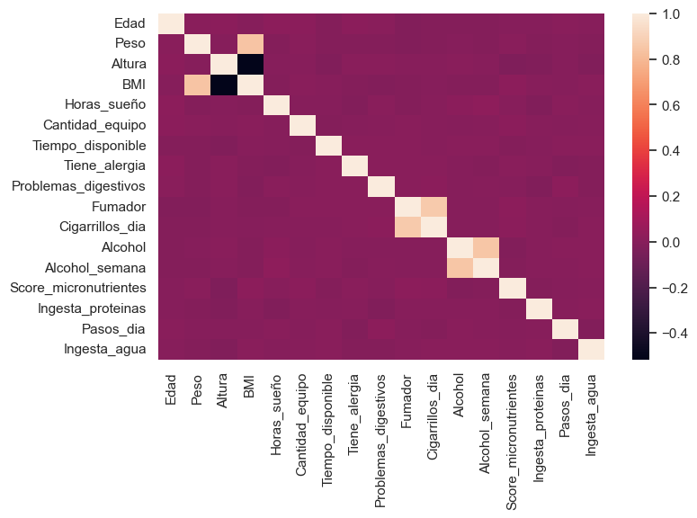

```python
print("\n\n◉ HEATMAP PARA VER CORRELACIÓN ENTRE VARIABLES:\n")
sns.heatmap(df.corr(numeric_only=True))
```

```python
print("\n\n◉ VERIFICAR VARIABLES CATEGORICAS:\n")

categoricas = df.select_dtypes(include="object").columns

for col in categoricas:
    print("\nVariable:", col)
    print(df[col].value_counts())
```

```
◉ VERIFICAR VARIABLES CATEGORICAS:


Variable: Gnereo
Gnereo
Femenino     4719
Masculino    4611
Otro          368
Name: count, dtype: int64

Variable: Objetivo
Objetivo
Ganancia muscular    2757
Perdida grasa        2594
General              2220
Resistencia          2123
grasa                   4
Name: count, dtype: int64

Variable: Condicion_salud
Condicion_salud
Ninguno               6030
Hipertension           814
Lesion                 764
Asma                   745
Diabetes               511
Enfermedad corazon     497
PCOS                   337
Name: count, dtype: int64

Variable: Nivel_Actividad
Nivel_Actividad
Moderado    3594
Bajo        3326
Alto        2778
Name: count, dtype: int64

Variable: Nivel_experiencia
Nivel_experiencia
Intermedio      4100
```

[output cut: 23 more lines]

```
Variable: Plan_entrenamiento
Plan_entrenamiento
Ninguno    3807
Medio      2945
Bajo       2290
Alto        656
Name: count, dtype: int64

Variable: Plan_nutrición
Plan_nutrición
Balanceado       4297
Sin plan         2522
Basico           2287
Especializado     592
Name: count, dtype: int64
```

```
◉ VERIFICAR OUTLIERS:
```

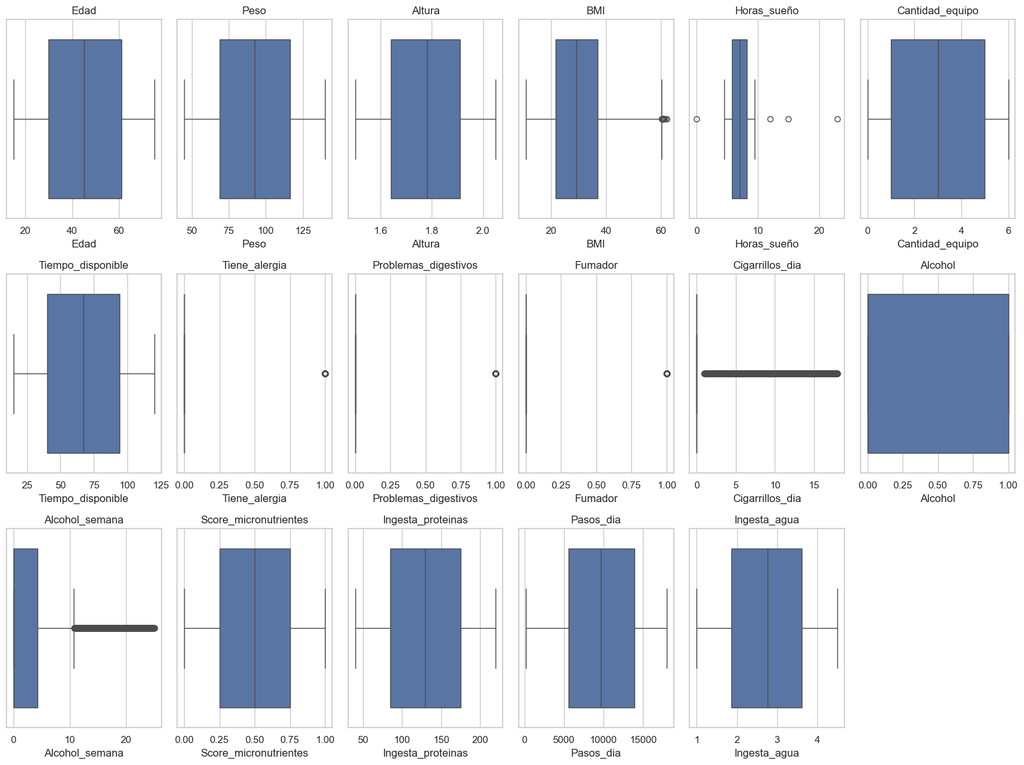

```python
print("\n\n◉ VERIFICAR OUTLIERS:\n")

numericas = df.select_dtypes(include=np.number).columns

col = 6
fil = int(np.ceil(len(numericas) / col))

fig, axes = plt.subplots(fil, col, figsize=(16, 4 * fil))

axes = axes.flatten()

for i, col in enumerate(numericas):
    sns.boxplot(x=df[col], ax=axes[i])
    axes[i].set_title(col)

for j in range(i + 1, len(axes)):
    fig.delaxes(axes[j])

plt.tight_layout()
plt.show()
```

# 3. Limpieza y preparación de datos:

Con base en los hallazgos del análisis anterior vamos a modificar los datos para luego proceder al modelado.

```python
df = df.drop(columns=["BMI"])
df = df.drop(columns=["Fumador"])
df = df.drop(columns=["Alcohol"])
```

# 4. Construcción del pipeline y division de conjuntos de datos

En esta sección se construye un pipeline de preprocesamiento que permitirá aplicar de manera sistemática y reproducible las transformaciones necesarias sobre los datos antes del entrenamiento de los modelos.

Una vez preparados los datos y definido el pipeline de preprocesamiento, se procede a dividir el conjunto de datos en subconjuntos de entrenamiento y prueba con 75% de los datos para entrenamiento y 25% de los datos para prueba.

```python
y_entrenamiento_plan = df["Plan_entrenamiento"]

y_nutricion_plan = df["Plan_nutrición"]

X = df.drop(columns=[
    "Plan_entrenamiento",
    "Plan_nutrición"
])

print(X.shape)
display(X.head())

numericas = X.select_dtypes(include=np.number).columns

categoricas = X.select_dtypes(include="object").columns

print("Variables numéricas:")
print(numericas)

print("\nVariables categóricas:")
print(categoricas)

print("\nCantidad variables numéricas:", len(numericas))
print("Cantidad variables categóricas:", len(categoricas))
```

```
(9698, 21)
```

|  | Edad | Gnereo | Peso | Altura | Objetivo | Condicion_salud | Nivel_Actividad | Nivel_experiencia | Dieta_preferida | Horas_sueño | ... | Cantidad_equipo | Tiempo_disponible | Tiene_alergia | Problemas_digestivos | Cigarrillos_dia | Alcohol_semana | Score_micronutrientes | Ingesta_proteinas | Pasos_dia | Ingesta_agua |
| --- | --- | --- | --- | --- | --- | --- | --- | --- | --- | --- | --- | --- | --- | --- | --- | --- | --- | --- | --- | --- | --- |
| 0 | 60 | Masculino | 73.7 | 1.61 | Resistencia | Hipertension | Bajo | Avanzado | Vegano | 5.5 | ... | 3 | 98 | 0 | 0 | 0.0 | 0.0 | 0.92 | 182.1 | 16485 | 2.49 |
| 1 | 17 | Femenino | 121.0 | 1.97 | Resistencia | Enfermedad corazon | Moderado | Principiante | Vegetariano | 6.9 | ... | 4 | 105 | 0 | 0 | 0.0 | 0.0 | 0.76 | 167.7 | 14256 | 2.04 |
| 2 | 43 | Masculino | 110.0 | 1.52 | General | Ninguno | Bajo | Principiante | No-Vegetariano | 6.0 | ... | 1 | 88 | 0 | 0 | 0.0 | 0.0 | 0.34 | 104.9 | 3050 | 2.53 |
| 3 | 49 | Otro | 73.6 | 1.96 | General | Ninguno | Moderado | Principiante | No-Vegetariano | 5.7 | ... | 5 | 96 | 0 | 0 | 0.0 | 0.0 | 0.71 | 59.5 | 2264 | 3.36 |
| 4 | 53 | Femenino | 80.8 | 1.76 | Resistencia | Hipertension | Alto | Principiante | Pescetariano | 5.8 | ... | 3 | 120 | 0 | 1 | 8.7 | 0.0 | 0.98 | 51.1 | 12774 | 1.90 |

5 rows × 21 columns

```
Variables numéricas:
Index(['Edad', 'Peso', 'Altura', 'Horas_sueño', 'Cantidad_equipo',
       'Tiempo_disponible', 'Tiene_alergia', 'Problemas_digestivos',
       'Cigarrillos_dia', 'Alcohol_semana', 'Score_micronutrientes',
       'Ingesta_proteinas', 'Pasos_dia', 'Ingesta_agua'],
      dtype='object')

Variables categóricas:
Index(['Gnereo', 'Objetivo', 'Condicion_salud', 'Nivel_Actividad',
       'Nivel_experiencia', 'Dieta_preferida', 'Entrenamiento_preferido'],
      dtype='object')

Cantidad variables numéricas: 14
Cantidad variables categóricas: 7
```

```python
pipeline_numerico = Pipeline([
    ("imputer", SimpleImputer(strategy="mean")),
    ("scaler", StandardScaler())
])

pipeline_categorico = Pipeline([
    ("imputer", SimpleImputer(strategy="most_frequent")),
    ("onehot", OneHotEncoder(handle_unknown="ignore"))
])

preprocesador = ColumnTransformer([
    ("num", pipeline_numerico, numericas),
    ("cat", pipeline_categorico, categoricas)
])
```

DIVISION DE CONJUNTOS DE DATOS RESPECTIVAMENTE:

1. PLAN DE ENTRENAMIENTO
2. PLAN DE NUTRICIÓN

```python
X_train_ent, X_test_ent, y_train_ent, y_test_ent = train_test_split(
    X,
    y_entrenamiento_plan,
    test_size=0.25,
    random_state=42,
    stratify=y_entrenamiento_plan
)
```

```python
X_train_nut, X_test_nut, y_train_nut, y_test_nut = train_test_split(
    X,
    y_nutricion_plan,
    test_size=0.25,
    random_state=42,
    stratify=y_nutricion_plan
)
```

# 6. Modelo de regresión logística para la predicción del plan de entrenamiento

En esta sección se construye un modelo de regresión logística para predecir la variable Plan_entrenamiento.

```python
pipeline_regresionlog_entrenamiento = Pipeline([
    ("preprocesador", preprocesador),
    ("modelo", LogisticRegression(max_iter=1000))
])
```

## Entrenamiento del modelo de regresión logística con búsqueda de hiperparámetros

Ya con el pipeline podemos iniciar con la búsqueda de hiperparámetros, su desempeño puede ajustarse mediante la selección de hiperparámetros como el valor de C (regularización), el algoritmo de optimización y el tipo de penalización (L1 o L2). Para esto se puede utilizar GridSearchCV para encontrar la mejor combinación de hiperparámetros que maximice el rendimiento del modelo.

```python
param_grid = [
    {
        "modelo__penalty": ["l2"],
        "modelo__solver": ["newton-cg", "lbfgs", "saga"],
        "modelo__C": [0.1, 0.2, 0.5, 0.8, 1]
    },
    {
        "modelo__penalty": ["l1"],
        "modelo__solver": ["saga"],
        "modelo__C": [0.1, 0.2, 0.5, 0.8, 1]
    }
]
```

Ahora vamos a hacer validación cruzada con un objeto de la clase StratifiedKFold() para evaluar el rendimiento del modelo de regresión logística con los mejores hiperparámetros encontrados. Esto nos permitirá obtener una estimación más robusta del desempeño del modelo en datos no vistos. Se hacen 10 n_splits para obtener una buena estimación del rendimiento del modelo y shuffle para asegurar que los datos se mezclen antes de dividirlos en los pliegues, manteniendo además la proporción de clases en cada partición, lo que ayuda a obtener una evaluación más representativa del modelo.

```python
cv_estratificada = StratifiedKFold(n_splits=10, shuffle=True, random_state=0)
```

Con GridSearchCV() se realiza una búsqueda exhaustiva sobre un espacio de hiperparámetros definido, utilizando validación cruzada para evaluar el rendimiento de cada combinación de hiperparámetros. Esto permite identificar la configuración que proporciona el mejor rendimiento del modelo en los datos de entrenamiento, lo que a su vez puede mejorar la capacidad del modelo para generalizar a datos no vistos. Como métrica se usa f1_macro para evaluar el rendimiento del modelo, ya que el problema es de clasificación multiclase y existe desbalance entre clases. Esta métrica calcula el F1-score de cada clase por separado y luego promedia los resultados, dando la misma importancia a todas las clases. Al optimizar el f1_macro, se busca un equilibrio entre precisión y recall en cada clase objetivo, evitando que las clases más frecuentes dominen la evaluación del modelo.

```python
grid_rl_entrenamiento = GridSearchCV(estimator=pipeline_regresionlog_entrenamiento, param_grid=param_grid, cv=cv_estratificada, scoring='f1_macro', n_jobs=-1)
```

```python
grid_rl_entrenamiento.fit(X_train_ent, y_train_ent)
```

```
GridSearchCV(cv=StratifiedKFold(n_splits=10, random_state=0, shuffle=True),
             estimator=Pipeline(steps=[('preprocesador',
                                        ColumnTransformer(transformers=[('num',
                                                                         Pipeline(steps=[('imputer',
                                                                                          SimpleImputer()),
                                                                                         ('scaler',
                                                                                          StandardScaler())]),
                                                                         Index(['Edad', 'Peso', 'Altura', 'Horas_sueño', 'Cantidad_equipo',
       'Tiempo_disponible', 'Tiene_alergia', 'Problemas_digestivos',...
       'Nivel_experiencia', 'Dieta_preferida', 'Entrenamiento_preferido'],
      dtype='object'))])),
                                       ('modelo',
                                        LogisticRegression(max_iter=1000))]),
             n_jobs=-1,
             param_grid=[{'modelo__C': [0.1, 0.2, 0.5, 0.8, 1],
                          'modelo__penalty': ['l2'],
                          'modelo__solver': ['newton-cg', 'lbfgs', 'saga']},
                         {'modelo__C': [0.1, 0.2, 0.5, 0.8, 1],
                          'modelo__penalty': ['l1'],
                          'modelo__solver': ['saga']}],
             scoring='f1_macro')
```

Ahora podemos ver los resultados de la búsqueda de hiperparámetros, incluyendo los mejores hiperparámetros encontrados y el mejor puntaje obtenido con esos hiperparámetros. Esto nos permitirá entender qué configuración de hiperparámetros es la más efectiva para nuestro modelo de regresión logística en la predicción del plan de entrenamiento.

```python
print("Mejores hiperparámetros:", grid_rl_entrenamiento.best_params_)
print("Mejor puntaje medio en CV (f1_macro):", grid_rl_entrenamiento.best_score_)
```

```
Mejores hiperparámetros: {'modelo__C': 0.8, 'modelo__penalty': 'l1', 'modelo__solver': 'saga'}
Mejor puntaje medio en CV (f1_macro): 0.8865751759082571
```

Podemos ver también el desempeño de las otras combinaciones de hiperparámetros para entender cómo afectan al rendimiento del modelo y tomar decisiones informadas sobre la configuración final del modelo.

```python
resultados = pd.DataFrame(grid_rl_entrenamiento.cv_results_)
cols = [
    'param_modelo__C',
    'mean_test_score',
    'std_test_score',
    'rank_test_score'
]
summary = resultados[cols].sort_values(by='rank_test_score')
print(summary)
```

```
    param_modelo__C  mean_test_score  std_test_score  rank_test_score
18              0.8         0.886575        0.010484                1
17              0.5         0.886516        0.011267                2
19              1.0         0.886291        0.011576                3
16              0.2         0.883409        0.012113                4
12              1.0         0.879500        0.014246                5
14              1.0         0.879500        0.014246                5
13              1.0         0.879323        0.013694                7
15              0.1         0.879000        0.016123                8
10              0.8         0.878626        0.014230                9
9               0.8         0.878278        0.013882               10
11              0.8         0.878172        0.014514               11
6               0.5         0.876339        0.014305               12
7               0.5         0.876235        0.014458               13
8               0.5         0.876235        0.014458               13
3               0.2         0.862979        0.018548               15
4               0.2         0.862955        0.018110               16
5               0.2         0.862545        0.018517               17
0               0.1         0.845174        0.017285               18
2               0.1         0.845039        0.017067               19
1               0.1         0.844953        0.017011               20
```

```python
best_model1 = grid_rl_entrenamiento.best_estimator_
```

## Evaluación del modelo

Ahora utilizamos el mejor modelo encontrado para hacer predicciones sobre el conjunto de prueba y evaluar su rendimiento utilizando métricas como precisión, recall, f1-score y matriz de confusión. Esto nos permitirá entender cómo se desempeña el modelo en datos no vistos y si es adecuado para su uso en la recomendación de planes de entrenamiento personalizados para los usuarios de SmartAlpes.

```python
y_pred_best_ent = best_model1.predict(X_test_ent)
```

Ahora con las predicciones podemos ver el reporte de clasificación y los resultados que arrojo el mejor modelo.

```python
print(classification_report(y_test_ent, y_pred_best_ent, target_names=['Alto', 'Bajo', 'Medio', 'Ninguno']))
```

```
              precision    recall  f1-score   support

        Alto       0.92      0.86      0.89       164
        Bajo       0.82      0.80      0.81       573
       Medio       0.89      0.90      0.90       736
     Ninguno       0.94      0.96      0.95       952

    accuracy                           0.90      2425
   macro avg       0.89      0.88      0.89      2425
weighted avg       0.90      0.90      0.90      2425
```

Las métricas macro avg y weighted avg corresponden a promedios globales del modelo. El macro avg calcula la media simple entre todas las clases, otorgando el mismo peso a cada una, por lo que permite evaluar qué tan equilibrado es el desempeño general. El weighted avg, por su parte, pondera cada clase según su cantidad de ejemplos, por lo que está más influido por las clases con mayor soporte. En este caso, ambos promedios son bastante cercanos, con valores alrededor de 0.89 y 0.90, lo que permite concluir que el modelo mantiene un rendimiento relativamente consistente entre las distintas clases y que, aunque existe cierta variación, el desbalance en el número de observaciones no distorsiona de forma importante la evaluación global.

La matriz de confusión es la siguiente:

```python
matriz_confusion = confusion_matrix(y_test_ent, y_pred_best_ent)
print(matriz_confusion)
```

```
[[141   0  23   0]
 [  0 457  58  58]
 [ 13  57 666   0]
 [  0  42   0 910]]
```

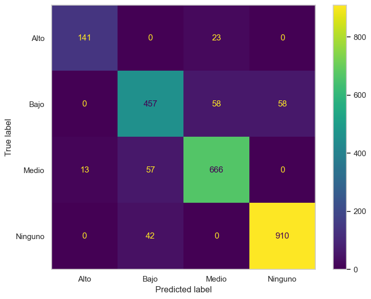

```python
fig, ax = plt.subplots(figsize=(8, 6))

ConfusionMatrixDisplay.from_predictions(
    y_test_ent,
    y_pred_best_ent,
    display_labels=['Alto', 'Bajo', 'Medio', 'Ninguno'],
    cmap='viridis',
    ax=ax,
    colorbar=True
)

ax.grid(False)              # quita las líneas de fondo
plt.tight_layout()
plt.show()
```

## Coefecientes del modelo de regresión logística

Podemos también analizar los coeficientes del modelo de regresión logística para entender la importancia relativa de cada variable en la predicción del plan de entrenamiento. Los coeficientes indican cómo cada variable afecta la probabilidad de que un usuario sea clasificado en una determinada categoría de plan de entrenamiento. Un coeficiente positivo indica que a medida que aumenta el valor de esa variable, también aumenta la probabilidad de ser clasificado en esa categoría, mientras que un coeficiente negativo indica lo contrario. Analizar estos coeficientes nos permite identificar qué características de los usuarios tienen mayor influencia en las recomendaciones de planes de entrenamiento y cómo estas características se relacionan con las diferentes categorías.

```python
preprocesador_entrenamiento = best_model1.named_steps['preprocesador']
log_reg_entrenamiento = best_model1.named_steps['modelo']
```

```python
feature_names_num = preprocesador_entrenamiento.transformers_[0][2]
ohe = preprocesador_entrenamiento.transformers_[1][1]
feature_names_cat = ohe.get_feature_names_out(preprocesador_entrenamiento.transformers_[1][2])
all_feature_names = np.concatenate([feature_names_num, feature_names_cat])
```

```python
coefs = log_reg_entrenamiento.coef_[0]
coef_df = pd.DataFrame({'feature': all_feature_names, 'coef': coefs})

coef_df = coef_df.sort_values('coef', ascending=False)
coef_df.head(30)
```

|  | feature | coef |
| --- | --- | --- |
| 32 | Nivel_experiencia_Avanzado | 21.551793 |
| 29 | Nivel_Actividad_Alto | 21.200315 |
| 17 | Objetivo_Ganancia muscular | 11.393659 |
| 5 | Tiempo_disponible | 4.222041 |
| 1 | Peso | 3.526932 |
| 22 | Condicion_salud_Asma | 0.424729 |
| 43 | Entrenamiento_preferido_Fuerza | 0.278031 |
| 14 | Gnereo_Femenino | 0.230290 |
| 11 | Ingesta_proteinas | 0.077448 |
| 3 | Horas_sueño | 0.072071 |
| 42 | Entrenamiento_preferido_Flexibilidad | 0.050458 |
| 8 | Cigarrillos_dia | 0.000000 |
| 9 | Alcohol_semana | 0.000000 |
| 4 | Cantidad_equipo | 0.000000 |
| 44 | Entrenamiento_preferido_Funcional | 0.000000 |
| 45 | Entrenamiento_preferido_Hit | 0.000000 |
| 39 | Dieta_preferida_Vegetariano | 0.000000 |
| 31 | Nivel_Actividad_Moderado | 0.000000 |
| 36 | Dieta_preferida_No-Vegetariano | 0.000000 |
| 37 | Dieta_preferida_Pescetariano | 0.000000 |
| 35 | Dieta_preferida_Animal | 0.000000 |
| 19 | Objetivo_Perdida grasa | 0.000000 |
| 27 | Condicion_salud_Ninguno | 0.000000 |
| 26 | Condicion_salud_Lesion | 0.000000 |
| 24 | Condicion_salud_Enfermedad corazon | 0.000000 |
| 23 | Condicion_salud_Diabetes | 0.000000 |
| 28 | Condicion_salud_PCOS | 0.000000 |
| 21 | Objetivo_grasa | 0.000000 |
| 15 | Gnereo_Masculino | 0.000000 |
| 16 | Gnereo_Otro | 0.000000 |

### Análisis de los coeficientes del modelo de regresión logística

```python
print("Top positivos:")
display(coef_df.head(10))

print("Top negativos:")
display(coef_df.sort_values('coef', ascending=True).head(10))
```

```
Top positivos:
```

|  | feature | coef |
| --- | --- | --- |
| 32 | Nivel_experiencia_Avanzado | 21.551793 |
| 29 | Nivel_Actividad_Alto | 21.200315 |
| 17 | Objetivo_Ganancia muscular | 11.393659 |
| 5 | Tiempo_disponible | 4.222041 |
| 1 | Peso | 3.526932 |
| 22 | Condicion_salud_Asma | 0.424729 |
| 43 | Entrenamiento_preferido_Fuerza | 0.278031 |
| 14 | Gnereo_Femenino | 0.230290 |
| 11 | Ingesta_proteinas | 0.077448 |
| 3 | Horas_sueño | 0.072071 |

```
Top negativos:
```

|  | feature | coef |
| --- | --- | --- |
| 2 | Altura | -1.989581 |
| 30 | Nivel_Actividad_Bajo | -0.726859 |
| 18 | Objetivo_General | -0.359333 |
| 25 | Condicion_salud_Hipertension | -0.278022 |
| 6 | Tiene_alergia | -0.238428 |
| 20 | Objetivo_Resistencia | -0.227529 |
| 40 | Entrenamiento_preferido_Balance | -0.207316 |
| 33 | Nivel_experiencia_Intermedio | -0.165592 |
| 38 | Dieta_preferida_Vegano | -0.130222 |
| 13 | Ingesta_agua | -0.074755 |

## Comparación de rendimientos sobre entrenamiento y test

```python
from IPython.display import Markdown

# Predicciones del mejor modelo
y_train_pred_best = best_model1.predict(X_train_ent)
y_test_pred_best = best_model1.predict(X_test_ent)

# Métricas en train
accuracy_train = accuracy_score(y_train_ent, y_train_pred_best)
recall_train = recall_score(y_train_ent, y_train_pred_best, average='macro')
precision_train = precision_score(y_train_ent, y_train_pred_best, average='macro')
f1_train = f1_score(y_train_ent, y_train_pred_best, average='macro')

# Métricas en test
accuracy_test = accuracy_score(y_test_ent, y_test_pred_best)
recall_test = recall_score(y_test_ent, y_test_pred_best, average='macro')
precision_test = precision_score(y_test_ent, y_test_pred_best, average='macro')
f1_test = f1_score(y_test_ent, y_test_pred_best, average='macro')

# Tabla en Markdown
texto = "\n\n"
texto += "|Métrica|Train|Test|\n"
texto += "|-------|-----|----|\n"
texto += f"|Exactitud|{accuracy_train:.2%}|{accuracy_test:.2%}|\n"
texto += f"|Recall macro|{recall_train:.2%}|{recall_test:.2%}|\n"
texto += f"|Precisión macro|{precision_train:.2%}|{precision_test:.2%}|\n"
texto += f"|F1-score macro|{f1_train:.2%}|{f1_test:.2%}|\n"

display(Markdown(texto))
```

| Métrica | Train | Test |
| --- | --- | --- |
| Exactitud | 90.14% | 89.65% |
| Recall macro | 89.29% | 87.95% |
| Precisión macro | 89.83% | 89.23% |
| F1-score macro | 89.55% | 88.56% |

### Análisis de rendimiento en entrenamiento y prueba

En conjunto, estas diferencias son pequeñas y esperables, por lo que no se evidencian señales fuertes de sobreajuste. El modelo no solo aprende adecuadamente sobre los datos de entrenamiento, sino que también conserva un rendimiento muy similar en prueba. Además, como se está usando un promedio **macro**, estas métricas tienen en cuenta el desempeño de todas las clases con el mismo peso, lo que es especialmente importante en este problema multiclase. En consecuencia, se puede concluir que el modelo presenta un comportamiento consistente, estable y suficientemente robusto para la tarea de clasificación del plan de entrenamiento.

# 7. Modelo de regresión logística para la predicción del plan de nutrición

En esta sección se construye un segundo modelo de regresión logística, enfocado en la predicción de la variable Plan_nutrición.

```python
pipeline_regresionlog_nutricion = Pipeline([
    ("preprocesador", preprocesador),
    ("modelo", LogisticRegression(max_iter=1000))
])

param_grid = [
    {
        "modelo__penalty": ["l2"],
        "modelo__solver": ["newton-cg", "lbfgs", "saga"],
        "modelo__C": [0.1, 0.2, 0.5, 0.8, 1]
    },
    {
        "modelo__penalty": ["l1"],
        "modelo__solver": ["saga"],
        "modelo__C": [0.1, 0.2, 0.5, 0.8, 1]
    }
]
```

```python
cv_estratificada = StratifiedKFold(
    n_splits=10,
    shuffle=True,
    random_state=0
)

grid_rl_nutricion = GridSearchCV(
    estimator=pipeline_regresionlog_nutricion,
    param_grid=param_grid,
    cv=cv_estratificada,
    scoring='f1_macro',
    n_jobs=-1
)

grid_rl_nutricion.fit(
    X_train_nut,
    y_train_nut
)

print("Mejores hiperparámetros:")
print(grid_rl_nutricion.best_params_)

print("Mejor F1_macro en CV:")
print(grid_rl_nutricion.best_score_)
```

```
Mejores hiperparámetros:
{'modelo__C': 1, 'modelo__penalty': 'l1', 'modelo__solver': 'saga'}
Mejor F1_macro en CV:
0.7380714811762972
```

```
               precision    recall  f1-score   support

   Balanceado       0.81      0.86      0.84      1074
       Basico       0.66      0.63      0.65       572
Especializado       0.66      0.45      0.54       148
     Sin plan       0.87      0.87      0.87       631

     accuracy                           0.79      2425
    macro avg       0.75      0.71      0.72      2425
 weighted avg       0.78      0.79      0.78      2425
```

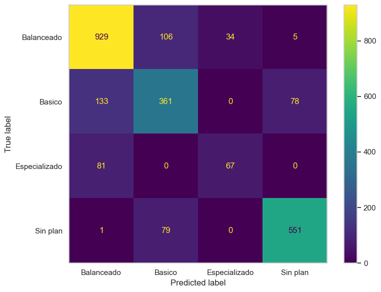

```python
best_model_nut = grid_rl_nutricion.best_estimator_

y_pred_best_nut = best_model_nut.predict(
    X_test_nut
)

print(classification_report(
    y_test_nut,
    y_pred_best_nut
))

matriz_confusion_nut = confusion_matrix(
    y_test_nut,
    y_pred_best_nut
)

fig, ax = plt.subplots(figsize=(8,6))

ConfusionMatrixDisplay.from_predictions(
    y_test_nut,
    y_pred_best_nut,
    cmap='viridis',
    ax=ax,
    colorbar=True
)

ax.grid(False)

plt.tight_layout()
plt.show()
```

```python
preprocesador_nut = best_model_nut.named_steps['preprocesador']

log_reg_nut = best_model_nut.named_steps['modelo']

feature_names_num = preprocesador_nut.transformers_[0][2]

ohe = preprocesador_nut.transformers_[1][1]

feature_names_cat = ohe.get_feature_names_out(
    preprocesador_nut.transformers_[1][2]
)

all_feature_names = np.concatenate([
    feature_names_num,
    feature_names_cat
])

coefs = log_reg_nut.coef_[0]

coef_df_nut = pd.DataFrame({
    'feature': all_feature_names,
    'coef': coefs
})

coef_df_nut = coef_df_nut.sort_values(
    'coef',
    ascending=False
)

display(coef_df_nut.head(10))

display(
    coef_df_nut.sort_values(
        'coef'
    ).head(10)
)
```

|  | feature | coef |
| --- | --- | --- |
| 1 | Peso | 0.906044 |
| 9 | Alcohol_semana | 0.862032 |
| 22 | Condicion_salud_Asma | 0.151529 |
| 37 | Dieta_preferida_Pescetariano | 0.142976 |
| 41 | Entrenamiento_preferido_Cardio | 0.083689 |
| 8 | Cigarrillos_dia | 0.037837 |
| 33 | Nivel_experiencia_Intermedio | 0.035086 |
| 39 | Dieta_preferida_Vegetariano | 0.026045 |
| 31 | Nivel_Actividad_Moderado | 0.023063 |
| 14 | Gnereo_Femenino | 0.019192 |

|  | feature | coef |
| --- | --- | --- |
| 18 | Objetivo_General | -4.972758 |
| 20 | Objetivo_Resistencia | -4.869155 |
| 10 | Score_micronutrientes | -0.812459 |
| 2 | Altura | -0.364088 |
| 11 | Ingesta_proteinas | -0.353839 |
| 32 | Nivel_experiencia_Avanzado | -0.115058 |
| 45 | Entrenamiento_preferido_Hit | -0.057319 |
| 7 | Problemas_digestivos | -0.040611 |
| 3 | Horas_sueño | -0.029984 |
| 26 | Condicion_salud_Lesion | -0.028811 |

```python
y_train_pred_nut = best_model_nut.predict(
    X_train_nut
)

y_test_pred_nut = best_model_nut.predict(
    X_test_nut
)

accuracy_train = accuracy_score(
    y_train_nut,
    y_train_pred_nut
)

accuracy_test = accuracy_score(
    y_test_nut,
    y_test_pred_nut
)

recall_train = recall_score(
    y_train_nut,
    y_train_pred_nut,
    average='macro'
)

recall_test = recall_score(
    y_test_nut,
    y_test_pred_nut,
    average='macro'
)

precision_train = precision_score(
    y_train_nut,
    y_train_pred_nut,
    average='macro'
)

precision_test = precision_score(
    y_test_nut,
    y_test_pred_nut,
    average='macro'
)

f1_train = f1_score(
    y_train_nut,
    y_train_pred_nut,
    average='macro'
)

f1_test = f1_score(
    y_test_nut,
    y_test_pred_nut,
    average='macro'
)

print("F1 Train:", f1_train)
print("F1 Test:", f1_test)
```

```
F1 Train: 0.7539196175195254
F1 Test: 0.7231966334921245
```

# 8. Modelo basado en árboles de decisión para la predicción del plan de entrenamiento

En esta sección se construye un modelo basado en árboles de decisión para la predicción de la variable Plan_entrenamiento.

A continuación, se crea el pipeline final. En este caso, se incluye un paso de preprocesamiento que utiliza OneHotEncoder para transformar las variables categóricas en variables numéricas, lo que es necesario para que el modelo de árbol de decisión pueda procesar los datos correctamente. Además, se incluye el modelo de árbol de decisión como el último paso del pipeline, lo que permite encadenar todas las transformaciones y el entrenamiento del modelo en una sola estructura.

```python
pipeline_arbol_entrenamiento = Pipeline([
    ("preprocesador", preprocesador),
    ("modelo", DecisionTreeClassifier())
])
```

### Entrenamiento del modelo de árbol de decisión con búsqueda de hiperparámetros

```python
param_grid = [
    {   # Hiperparámetros del criterio de partición
        'modelo__criterion': ['gini', 'entropy', 'log_loss'],
        'modelo__splitter': ['best', 'random'],
        'modelo__max_features': ['sqrt', 'log2', None],

        # Hiperparámetros de complejidad del árbol
        'modelo__max_depth': [5, 10, 15],
        'modelo__max_leaf_nodes': [3, 9, 18, 27]
    }
]
```

Ahora definimos un objeto de la clase KFold() para realizar validación cruzada durante la búsqueda de hiperparámetros del modelo de árbol de decisión. Esto nos permitirá evaluar el rendimiento del modelo de manera más robusta y obtener una estimación más precisa de su capacidad para generalizar a datos no vistos. Al usar K-Fold, dividimos el conjunto de entrenamiento en K subconjuntos (o pliegues) y entrenamos el modelo K veces, cada vez utilizando un pliegue diferente como conjunto de validación y los restantes como conjunto de entrenamiento. Esto ayuda a reducir la varianza en la evaluación del modelo y proporciona una mejor comprensión de su desempeño en diferentes particiones de los datos.

```python
kfold = KFold(n_splits=10, shuffle=True, random_state=42)
```

Para la búsqueda de hiperparámetros utilizaremos GridSearchCV() para evaluar diferentes combinaciones de hiperparámetros del modelo de árbol de decisión, utilizando validación cruzada con K-Fold para obtener una estimación más robusta del rendimiento del modelo. La métrica utilizada para evaluar el rendimiento durante la búsqueda de hiperparámetros será el F1-score macro, que es adecuado para problemas de clasificación multiclase y permite evaluar el equilibrio entre precisión y recall en cada clase objetivo. Al optimizar el F1-score macro, se busca mejorar la capacidad del modelo para clasificar correctamente todas las clases, especialmente en situaciones donde existe desbalance entre ellas.

```python
decision_tree_grid_ent = GridSearchCV(estimator=pipeline_arbol_entrenamiento, param_grid=param_grid, cv=kfold, scoring='f1_macro', n_jobs=-1, verbose=1)
```

```python
decision_tree_grid_ent.fit(X_train_ent, y_train_ent)
```

```
Fitting 10 folds for each of 216 candidates, totalling 2160 fits
```

```
GridSearchCV(cv=KFold(n_splits=10, random_state=42, shuffle=True),
             estimator=Pipeline(steps=[('preprocesador',
                                        ColumnTransformer(transformers=[('num',
                                                                         Pipeline(steps=[('imputer',
                                                                                          SimpleImputer()),
                                                                                         ('scaler',
                                                                                          StandardScaler())]),
                                                                         Index(['Edad', 'Peso', 'Altura', 'Horas_sueño', 'Cantidad_equipo',
       'Tiempo_disponible', 'Tiene_alergia', 'Problemas_digestivos',
       'Cigarril...
       'Nivel_experiencia', 'Dieta_preferida', 'Entrenamiento_preferido'],
      dtype='object'))])),
                                       ('modelo', DecisionTreeClassifier())]),
             n_jobs=-1,
             param_grid=[{'modelo__criterion': ['gini', 'entropy', 'log_loss'],
                          'modelo__max_depth': [5, 10, 15],
                          'modelo__max_features': ['sqrt', 'log2', None],
                          'modelo__max_leaf_nodes': [3, 9, 18, 27],
                          'modelo__splitter': ['best', 'random']}],
             scoring='f1_macro', verbose=1)
```

Exploramos los resultados de la búsqueda de hiperparámetros:

```python
print('Mejores hiperparámetros:\n')
display(decision_tree_grid_ent.best_params_)
print(f'\nMejor puntaje medio en CV: {decision_tree_grid_ent.best_score_:.3f}')
```

```
Mejores hiperparámetros:
```

```
{'modelo__criterion': 'gini',
 'modelo__max_depth': 10,
 'modelo__max_features': None,
 'modelo__max_leaf_nodes': 27,
 'modelo__splitter': 'best'}
```

```
Mejor puntaje medio en CV: 0.911
```

```python
results = pd.DataFrame(decision_tree_grid_ent.cv_results_)
cols = [
    'param_modelo__criterion',
    'mean_test_score',
    'std_test_score',
    'rank_test_score'
]
summary = results[cols].sort_values(by='rank_test_score')
display(summary)
```

|  | param_modelo__criterion | mean_test_score | std_test_score | rank_test_score |
| --- | --- | --- | --- | --- |
| 46 | gini | 0.910725 | 0.011536 | 1 |
| 70 | gini | 0.910725 | 0.011536 | 1 |
| 22 | gini | 0.900500 | 0.011790 | 3 |
| 118 | entropy | 0.897403 | 0.016677 | 4 |
| 190 | log_loss | 0.897403 | 0.016677 | 4 |
| ... | ... | ... | ... | ... |
| 9 | gini | 0.246985 | 0.065115 | 212 |
| 152 | log_loss | 0.245082 | 0.037457 | 213 |
| 201 | log_loss | 0.241814 | 0.066191 | 214 |
| 192 | log_loss | 0.239389 | 0.043251 | 215 |
| 105 | entropy | 0.224966 | 0.049765 | 216 |

216 rows × 4 columns

### Evaluación del mejor modelo

Ahora se va utilizar el mejor modelo que se encontró en el proceso de GridSearch, almacenado en `decision_tree_grid_ent.best_estimator_`, para aplicar el pipeline completo sobre el conjunto de prueba y evaluar su rendimiento utilizando métricas como precisión, recall, F1-score y matriz de confusión. Esto nos permitirá entender cómo se desempeña el modelo de árbol de decisión en datos no vistos y si es adecuado para su uso en la recomendación de planes de entrenamiento personalizados para los usuarios de SmartAlpes.

```python
best_model2 = decision_tree_grid_ent.best_estimator_
```

```python
y_pred_best_ent_arbol = best_model2.predict(X_test_ent)
print(classification_report(y_test_ent, y_pred_best_ent_arbol))
```

```
              precision    recall  f1-score   support

        Alto       0.78      0.97      0.86       164
        Bajo       0.85      0.91      0.88       573
       Medio       0.96      0.87      0.92       736
     Ninguno       0.97      0.95      0.96       952

    accuracy                           0.92      2425
   macro avg       0.89      0.93      0.90      2425
weighted avg       0.93      0.92      0.92      2425
```

### Análisis del reporte de clasificación

Podemos ver en detalle los resultados del reporte de clasificación, para ello utilizamos la matriz de confusión dada las predicciones del conjunto de evaluación.

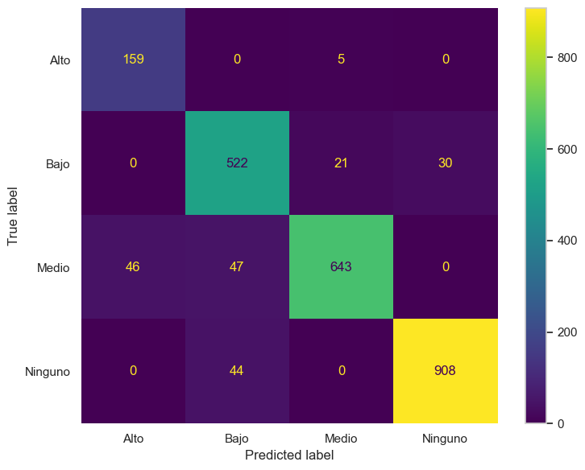

```python
fig, ax = plt.subplots(figsize=(8, 6))

ConfusionMatrixDisplay.from_predictions(
    y_test_ent,
    y_pred_best_ent_arbol,
    display_labels=['Alto', 'Bajo', 'Medio', 'Ninguno'],
    cmap='viridis',
    colorbar=True,
    ax=ax,
    values_format='d'
)

ax.grid(False)
for spine in ax.spines.values():
    spine.set_visible(False)

plt.tight_layout()
plt.show()
```

### Análisis de la matriz de confusión

A continuación, se analizará el modelo entrenado para revisar las reglas de decisión aprendidas por el árbol y entender cómo se están tomando las decisiones para recomendar cada plan de entrenamiento. Esto nos permitirá identificar qué características de los usuarios son más relevantes para cada categoría y cómo el modelo está utilizando esa información para generar las recomendaciones personalizadas. Además, de analizar las caracteristicas más importantes, se pueden visualizar las reglas de decisión del árbol para entender mejor la lógica detrás de las recomendaciones y cómo se están segmentando los usuarios en función de sus características. Esto nos ayudará a interpretar el modelo y a identificar posibles áreas de mejora o ajustes necesarios para optimizar las recomendaciones de planes de entrenamiento.

```python
best_preprocessor = best_model2.named_steps['preprocesador']
best_decision_tree = best_model2.named_steps['modelo']
```

### Importancia de las variables para describir la variable objetivo

```python
feature_names = best_preprocessor.get_feature_names_out()
feature_names = [name.split('__')[-1] for name in feature_names]
importances = best_decision_tree.feature_importances_
feature_importance_df = pd.Series(importances, index=feature_names).sort_values(ascending=False)
```

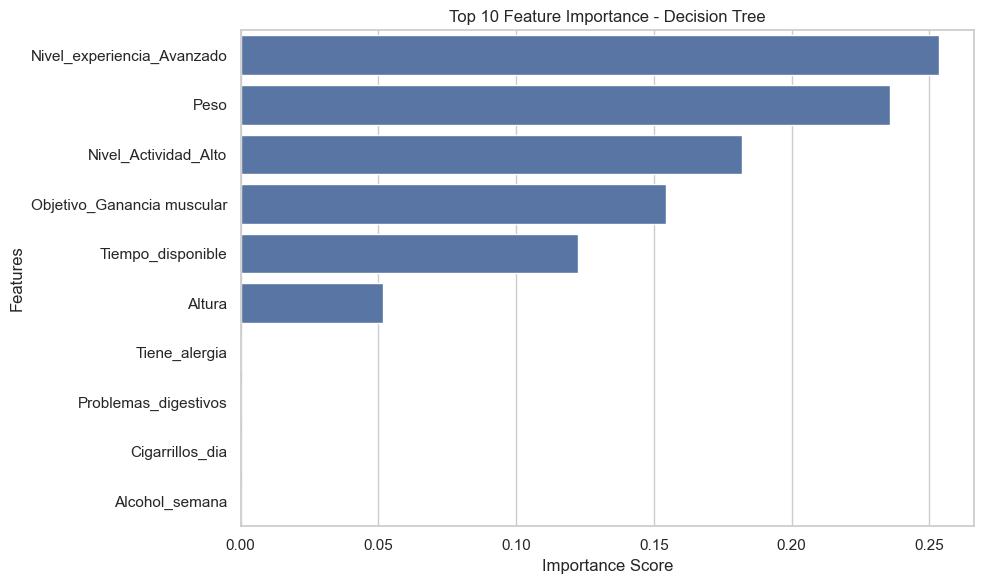

```python
top_features = feature_importance_df.head(10)

plt.figure(figsize=(10, 6))
sns.barplot(x=top_features.values, y=top_features.index)

plt.title('Top 10 Feature Importance - Decision Tree')
plt.xlabel('Importance Score')
plt.ylabel('Features')
plt.tight_layout()
plt.show()
```

### Análisis de la importancia de variables del árbol de decisión

La gráfica de importancia de variables muestra que el modelo de árbol de decisión concentra casi toda su capacidad predictiva en un grupo muy reducido de características. En particular, **Nivel_experiencia_Avanzado** aparece como la variable más influyente, seguida por **Peso**, **Nivel_Actividad_Alto**, **Objetivo_Ganancia muscular** y **Tiempo_disponible**. Esto indica que el árbol basa la mayor parte de sus decisiones en variables relacionadas con el nivel de experiencia del usuario, su condición física, su objetivo principal y el tiempo que puede dedicar al entrenamiento, lo cual resulta coherente con la lógica de recomendación de planes personalizados.

En conjunto, la gráfica sugiere que la recomendación del plan de entrenamiento está fuertemente explicada por unas pocas características clave del perfil del usuario. Esto favorece la interpretabilidad del modelo, ya que permite identificar con claridad qué factores están guiando las decisiones. Sin embargo, también puede ser una señal de que varias variables del conjunto de datos son redundantes o poco informativas para este árbol en particular, por lo que sería razonable explorar en análisis posteriores si el modelo mantiene un desempeño similar al trabajar con un subconjunto más reducido de variables relevantes.

También podemos generar el árbol creado. Para esto se utiliza la función `plot_tree` de la biblioteca `sklearn.tree`, que permite visualizar la estructura del árbol de decisión entrenado. Esta visualización muestra cómo el modelo toma decisiones en función de las características de los usuarios, con cada nodo representando una pregunta sobre una variable específica y cada rama representando una posible respuesta. Al analizar el árbol, podemos entender mejor la lógica detrás de las recomendaciones de planes de entrenamiento y cómo se segmentan los usuarios en función de sus características. Esto nos ayudará a interpretar el modelo y a identificar posibles áreas de mejora o ajustes necesarios para optimizar las recomendaciones personalizadas.

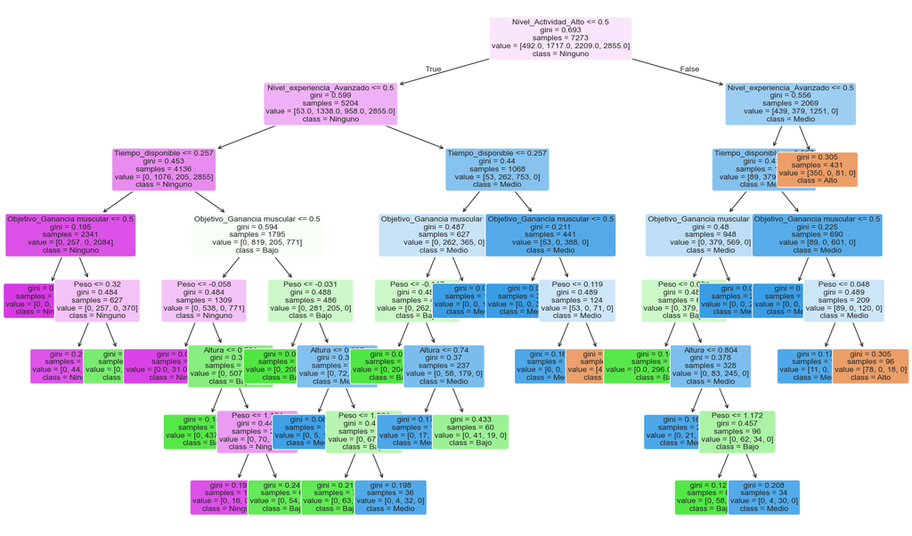

```python
plt.figure(figsize=(20, 12))
plot_tree(
    best_decision_tree,
    feature_names=feature_names,
    class_names=best_decision_tree.classes_,
    filled=True,
    rounded=True,
    fontsize=10
)
plt.show()
```

### Análisis de la estructura del árbol de decisión

Al inspeccionar la arquitectura del árbol, se observa que las decisiones más importantes del modelo se toman desde los nodos superiores, donde aparecen variables como **Nivel_Actividad_Alto**, **Nivel_experiencia_Avanzado**, **Tiempo_disponible** y **Objetivo_Ganancia muscular**. Esto indica que el árbol organiza primero a los usuarios según su nivel de actividad y experiencia, para luego refinar la recomendación con variables asociadas al tiempo disponible y al objetivo principal del entrenamiento. En otras palabras, el modelo está priorizando características que reflejan tanto la capacidad física del usuario como su intención de entrenamiento.

Cada nodo del árbol resume cinco elementos clave: la condición de partición, el valor de impureza **gini**, el número de muestras que llegan al nodo, la distribución de clases en `value` y la clase predicha. Por ejemplo, en la raíz se observa una división sobre **Nivel_Actividad_Alto**, lo que sugiere que esta variable es uno de los criterios iniciales más determinantes para separar los perfiles de usuarios. A partir de allí, las ramas muestran cómo el modelo distingue grupos con comportamientos diferentes: hacia un lado predominan recomendaciones como **Ninguno**, mientras que hacia el otro aparecen con más fuerza clases como **Medio** y **Alto**, dependiendo de la combinación de experiencia, tiempo disponible y objetivo.

También se aprecia que, a medida que el árbol desciende, las reglas se vuelven más específicas y combinan varias condiciones para asignar una recomendación final. Por ejemplo, usuarios con mayor experiencia, alta actividad y objetivo de ganancia muscular tienden a quedar asociados a planes más exigentes, mientras que perfiles con menor experiencia o menor disponibilidad de tiempo terminan en categorías menos intensas o incluso en **Ninguno**. Esta visualización resulta especialmente útil porque permite traducir el modelo en reglas comprensibles, lo que fortalece su interpretabilidad. Sin embargo, también deja ver una limitación: aunque el árbol es explicable, su tamaño y cantidad de nodos hacen que la lectura completa sea más difícil a medida que aumenta la profundidad, por lo que conviene centrarse en las primeras divisiones para entender la lógica principal del modelo.

También podemos ver el modelo de manera textual.

```python
arbol_reglas = export_text(best_decision_tree, feature_names=list(feature_names))
print(arbol_reglas)
```

```
|--- Nivel_Actividad_Alto <= 0.50
|   |--- Nivel_experiencia_Avanzado <= 0.50
|   |   |--- Tiempo_disponible <= 0.26
|   |   |   |--- Objetivo_Ganancia muscular <= 0.50
|   |   |   |   |--- class: Ninguno
|   |   |   |--- Objetivo_Ganancia muscular >  0.50
|   |   |   |   |--- Peso <= 0.32
|   |   |   |   |   |--- class: Ninguno
|   |   |   |   |--- Peso >  0.32
|   |   |   |   |   |--- class: Bajo
|   |   |--- Tiempo_disponible >  0.26
|   |   |   |--- Objetivo_Ganancia muscular <= 0.50
|   |   |   |   |--- Peso <= -0.06
|   |   |   |   |   |--- class: Ninguno
|   |   |   |   |--- Peso >  -0.06
|   |   |   |   |   |--- Altura <= 0.55
|   |   |   |   |   |   |--- class: Bajo
|   |   |   |   |   |--- Altura >  0.55
|   |   |   |   |   |   |--- Peso <= 1.12
|   |   |   |   |   |   |   |--- class: Ninguno
|   |   |   |   |   |   |--- Peso >  1.12
|   |   |   |   |   |   |   |--- class: Bajo
|   |   |   |--- Objetivo_Ganancia muscular >  0.50
|   |   |   |   |--- Peso <= -0.03
|   |   |   |   |   |--- class: Bajo
|   |   |   |   |--- Peso >  -0.03
|   |   |   |   |   |--- Altura <= 0.24
|   |   |   |   |   |   |--- class: Medio
|   |   |   |   |   |--- Altura >  0.24
|   |   |   |   |   |   |--- Peso <= 1.02
|   |   |   |   |   |   |   |--- class: Bajo
|   |   |   |   |   |   |--- Peso >  1.02
|   |   |   |   |   |   |   |--- class: Medio
|   |--- Nivel_experiencia_Avanzado >  0.50
|   |   |--- Tiempo_disponible <= 0.26
|   |   |   |--- Objetivo_Ganancia muscular <= 0.50
|   |   |   |   |--- Peso <= -0.15
|   |   |   |   |   |--- class: Bajo
|   |   |   |   |--- Peso >  -0.15
|   |   |   |   |   |--- Altura <= 0.74
```

[output cut: 24 more lines]

```
|   |   |   |   |   |   |   |--- class: Bajo
|   |   |   |   |   |   |--- Peso >  1.17
|   |   |   |   |   |   |   |--- class: Medio
|   |   |   |--- Objetivo_Ganancia muscular >  0.50
|   |   |   |   |--- class: Medio
|   |   |--- Tiempo_disponible >  0.26
|   |   |   |--- Objetivo_Ganancia muscular <= 0.50
|   |   |   |   |--- class: Medio
|   |   |   |--- Objetivo_Ganancia muscular >  0.50
|   |   |   |   |--- Peso <= 0.05
|   |   |   |   |   |--- class: Medio
|   |   |   |   |--- Peso >  0.05
|   |   |   |   |   |--- class: Alto
|   |--- Nivel_experiencia_Avanzado >  0.50
|   |   |--- class: Alto
```

## Análisis de resultados del árbol para el plan de entrenamiento

El árbol de decisión construido para predecir el **plan de entrenamiento** muestra que la recomendación final depende principalmente de un conjunto reducido de variables: el **nivel de actividad**, el **nivel de experiencia**, el **tiempo disponible**, el **objetivo del usuario** y, en algunos nodos más específicos, variables como el **peso**. Esto indica que el modelo está siguiendo una lógica coherente con el problema, ya que primero separa a los usuarios según su nivel general de preparación física y sus metas de entrenamiento, y luego refina la decisión con características adicionales que ayudan a distinguir entre planes de distinta intensidad.

A partir de las reglas textuales del árbol, se observa que los perfiles con **mayor nivel de actividad**, **experiencia avanzada** y **objetivo de ganancia muscular** tienden a ser dirigidos hacia planes más exigentes, como **Alto** o **Medio**. En cambio, los usuarios con menor experiencia, menor disponibilidad de tiempo o sin señales claras de alta exigencia suelen quedar clasificados en categorías como **Bajo** o **Ninguno**. Esto sugiere que el modelo está reproduciendo una estructura de decisión razonable: asigna planes más intensos a usuarios con mayor capacidad o compromiso, y planes menos demandantes a perfiles con menor preparación o menor posibilidad de entrenamiento constante.

Desde el punto de vista interpretativo, una de las principales fortalezas de este árbol es que permite traducir el proceso de clasificación en reglas explícitas y comprensibles. Esto facilita explicar por qué un usuario recibe una recomendación determinada y puede ser útil en una plataforma de bienestar o fitness, donde la transparencia del sistema aporta confianza. Sin embargo, también se observa una limitación importante: aunque las reglas son interpretables, el árbol completo incluye muchas ramificaciones, por lo que la lectura detallada de toda la estructura se vuelve más difícil. En la práctica, las primeras divisiones son las más valiosas para entender la lógica general del modelo, mientras que las ramas profundas capturan casos más específicos.

En conjunto, los resultados del árbol indican que el modelo logra representar de forma clara la relación entre las características del usuario y el tipo de plan recomendado. Además, las reglas encontradas son consistentes con el análisis previo de importancia de variables y con el buen desempeño observado en las métricas de evaluación. Esto permite concluir que el árbol de decisión no solo es útil como herramienta predictiva, sino también como un modelo explicable que ayuda a entender qué factores pesan más en la recomendación de planes de entrenamiento personalizados.

# 9. Modelo basado en árboles de decisión para la predicción del plan de nutrición

En esta sección se desarrolla el modelo basado en arboles de decisión para predecir la variable Plan_nutrición

Se emplea la misma metodología utilizada previamente para el plan de entrenamiento para hacer una comparación entre los modelos.

Haremos:

- Construccion de un pipeline del preprocesamiento y el modelo.
- Búsqueda de hiperparámetros mediante validación cruzada.
- Evaluación del modelo mediante métricas de clasificación.
- Visualización de la matriz de confusion.
- Identificación de las variables más importantes.
- Visualización de la estructura del árbol.

Este modelo permite comprender qué características influyen en la recomendación de planes nutricionales para que se hagan correctametne las preducciones.

```python
pipeline_arbol_nutricion = Pipeline([
    ("preprocesador", preprocesador),
    ("modelo", DecisionTreeClassifier())
])

param_grid_arbol_nut = [
    {
        "modelo__criterion": ["gini", "entropy", "log_loss"],
        "modelo__splitter": ["best", "random"],
        "modelo__max_features": ["sqrt", "log2", None],

        "modelo__max_depth": [5, 10, 15],
        "modelo__max_leaf_nodes": [3, 9, 18, 27]
    }
]
```

```python
cv_arbol_nut = StratifiedKFold(
    n_splits=10,
    shuffle=True,
    random_state=42
)

decision_tree_grid_nut = GridSearchCV(
    estimator=pipeline_arbol_nutricion,
    param_grid=param_grid_arbol_nut,
    cv=cv_arbol_nut,
    scoring='f1_macro',
    n_jobs=-1,
    verbose=1
)

decision_tree_grid_nut.fit(
    X_train_nut,
    y_train_nut
)

print("Mejores hiperparámetros:\n")
display(decision_tree_grid_nut.best_params_)

print(
    f"\nMejor puntaje medio en CV: "
    f"{decision_tree_grid_nut.best_score_:.3f}"
)
```

```
Fitting 10 folds for each of 216 candidates, totalling 2160 fits
Mejores hiperparámetros:
```

```
{'modelo__criterion': 'gini',
 'modelo__max_depth': 10,
 'modelo__max_features': None,
 'modelo__max_leaf_nodes': 27,
 'modelo__splitter': 'best'}
```

```
Mejor puntaje medio en CV: 0.848
```

```python
results_nut = pd.DataFrame(
    decision_tree_grid_nut.cv_results_
)

cols = [
    'param_modelo__criterion',
    'mean_test_score',
    'std_test_score',
    'rank_test_score'
]

summary_nut = results_nut[cols].sort_values(
    by='rank_test_score'
)

display(summary_nut)
```

|  | param_modelo__criterion | mean_test_score | std_test_score | rank_test_score |
| --- | --- | --- | --- | --- |
| 46 | gini | 0.848483 | 0.010201 | 1 |
| 70 | gini | 0.848483 | 0.010201 | 1 |
| 118 | entropy | 0.840713 | 0.020552 | 3 |
| 142 | entropy | 0.840713 | 0.020552 | 3 |
| 190 | log_loss | 0.840713 | 0.020552 | 3 |
| ... | ... | ... | ... | ... |
| 25 | gini | 0.231185 | 0.069247 | 212 |
| 105 | entropy | 0.231180 | 0.066351 | 213 |
| 8 | gini | 0.229820 | 0.078044 | 214 |
| 121 | entropy | 0.228621 | 0.061540 | 215 |
| 129 | entropy | 0.211374 | 0.071222 | 216 |

216 rows × 4 columns

```python
best_model_nut2 = decision_tree_grid_nut.best_estimator_

y_pred_best_nut_arbol = best_model_nut2.predict(
    X_test_nut
)

print(
    classification_report(
        y_test_nut,
        y_pred_best_nut_arbol
    )
)
```

```
               precision    recall  f1-score   support

   Balanceado       0.87      0.93      0.90      1074
       Basico       0.80      0.73      0.76       572
Especializado       0.84      0.73      0.78       148
     Sin plan       0.92      0.91      0.92       631

     accuracy                           0.87      2425
    macro avg       0.86      0.82      0.84      2425
 weighted avg       0.86      0.87      0.86      2425
```

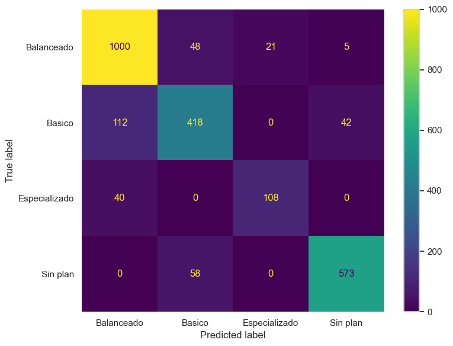

```python
fig, ax = plt.subplots(figsize=(8, 6))

ConfusionMatrixDisplay.from_predictions(
    y_test_nut,
    y_pred_best_nut_arbol,
    cmap='viridis',
    colorbar=True,
    ax=ax,
    values_format='d'
)

ax.grid(False)

for spine in ax.spines.values():
    spine.set_visible(False)

plt.tight_layout()
plt.show()
```

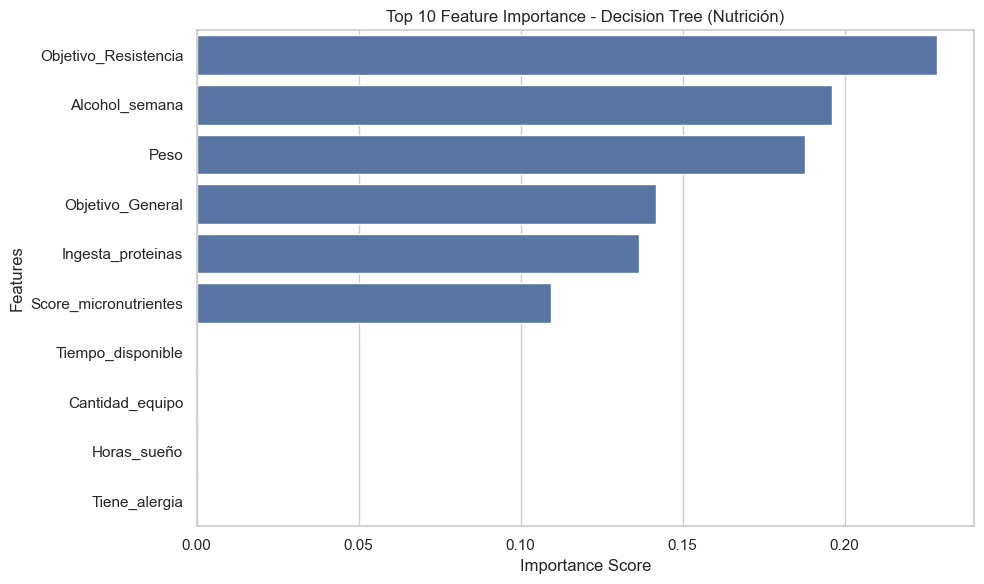

```python
best_preprocessor_nut = best_model_nut2.named_steps['preprocesador']

best_decision_tree_nut = best_model_nut2.named_steps['modelo']

feature_names_nut = best_preprocessor_nut.get_feature_names_out()

feature_names_nut = [
    name.split('__')[-1]
    for name in feature_names_nut
]

importances_nut = best_decision_tree_nut.feature_importances_

feature_importance_df_nut = pd.Series(
    importances_nut,
    index=feature_names_nut
).sort_values(ascending=False)

top_features_nut = feature_importance_df_nut.head(10)

plt.figure(figsize=(10,6))

sns.barplot(
    x=top_features_nut.values,
    y=top_features_nut.index
)

plt.title(
    'Top 10 Feature Importance - Decision Tree (Nutrición)'
)

plt.xlabel('Importance Score')

plt.ylabel('Features')

plt.tight_layout()

plt.show()
```

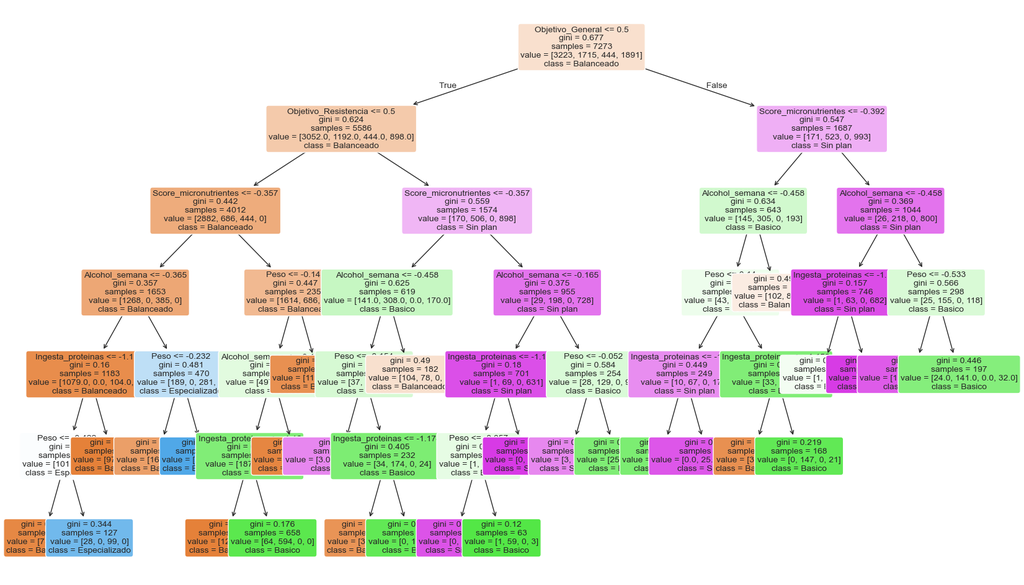

```python
plt.figure(figsize=(20,12))

plot_tree(
    best_decision_tree_nut,
    feature_names=feature_names_nut,
    class_names=best_decision_tree_nut.classes_,
    filled=True,
    rounded=True,
    fontsize=10
)

plt.show()
```

## Análisis de la estructura del árbol de decisión para el plan de nutrición

Al analizar la estructura del árbol de decisión para el plan de nutricion observamos que las decisiones iniciales se concentran en un conjunto reducido de variables clave. Estas variables suelen corresponder a características relacionadas con el estado físico, los hábitos alimenticios y los objetivos personales de los usuarios.

Los nodos superiores del árbol representan las decisiones más relevantes, ya que separan a los usuarios en grandes grupos según características dominantes. A medida vamos viendo las ramas del arbol, las reglas se vuelven más específicas y combinan múltiples variables para definir la recomendación final del plan nutricional.

Para ambos casos nos fue muy util este modelo para que al analizar usuarios con hábitos nutricionales más estructurados o con objetivos específicos reciban planes más personalizados, mientras que perfiles con menor información relevante o menor compromiso pueden ser asignados a planes básicos o dejaros sin plan.

# 10. Tabla comparativa de modelos

Analizamos el rendimiento sobre test de los mejores dos modelos, por cada objetivo, obtenidos en los puntos anteriores, con base en las métricas recall, precisión y F1-score.

```python
# Métricas modelo logística entrenamiento

precision_rl_ent = precision_score(
    y_test_ent,
    y_pred_best_ent,
    average="macro"
)

recall_rl_ent = recall_score(
    y_test_ent,
    y_pred_best_ent,
    average="macro"
)

f1_rl_ent = f1_score(
    y_test_ent,
    y_pred_best_ent,
    average="macro"
)


# Metricas modelo logística nutrición

precision_rl_nut = precision_score(
    y_test_nut,
    y_pred_best_nut,
    average="macro"
)

recall_rl_nut = recall_score(
    y_test_nut,
    y_pred_best_nut,
    average="macro"
)

f1_rl_nut = f1_score(
    y_test_nut,
    y_pred_best_nut,
    average="macro"
)


# Metricas arbol entrenamiento

precision_dt_ent = precision_score(
    y_test_ent,
    y_pred_best_ent_arbol,
    average="macro"
)

recall_dt_ent = recall_score(
    y_test_ent,
    y_pred_best_ent_arbol,
    average="macro"
)

f1_dt_ent = f1_score(
    y_test_ent,
    y_pred_best_ent_arbol,
    average="macro"
)


# Metricas arbol nutricion

precision_dt_nut = precision_score(
    y_test_nut,
    y_pred_best_nut_arbol,
    average="macro"
)

recall_dt_nut = recall_score(
    y_test_nut,
    y_pred_best_nut_arbol,
    average="macro"
)

f1_dt_nut = f1_score(
    y_test_nut,
    y_pred_best_nut_arbol,
    average="macro"
)


tabla_comparacion = pd.DataFrame({

    "Modelo": [
        "Regresión Logística - Entrenamiento",
        "Árbol de Decisión - Entrenamiento",
        "Regresión Logística - Nutrición",
        "Árbol de Decisión - Nutrición"
    ],

    "Precisión": [
        precision_rl_ent,
        precision_dt_ent,
        precision_rl_nut,
        precision_dt_nut
    ],

    "Recall": [
        recall_rl_ent,
        recall_dt_ent,
        recall_rl_nut,
        recall_dt_nut
    ],

    "F1-score": [
        f1_rl_ent,
        f1_dt_ent,
        f1_rl_nut,
        f1_dt_nut
    ]

})

display(tabla_comparacion)
```

|  | Modelo | Precisión | Recall | F1-score |
| --- | --- | --- | --- | --- |
| 0 | Regresión Logística - Entrenamiento | 0.892294 | 0.879522 | 0.885614 |
| 1 | Árbol de Decisión - Entrenamiento | 0.889078 | 0.926982 | 0.904552 |
| 2 | Regresión Logística - Nutrición | 0.751422 | 0.705507 | 0.723197 |
| 3 | Árbol de Decisión - Nutrición | 0.856792 | 0.824920 | 0.839274 |

## Análisis comparativo de modelos

### Plan de entrenamiento

En la predicción del plan de entrenamiento, el modelo basado en árbol de decisión presenta el mejor desempeño general, alcanzando un F1-score de 0.904, mejor que el que obtenido por el modelo de regresión logística de 0.886.

Aunque ambos modelos muestran valores similares en precisión, el árbol de decisión logra un recall mayor de 0.927, lo que indica que es capaz de identificar correctamente un mayor número de casos reales en cada categoría.

Entonces podemos decir que el árbol de decisión es el modelo más adecuado para la predicción del plan de entrenamiento, ya que ofrece el mejor equilibrio entre precisión y recall.

### Plan de nutrición

En el caso de la predicción del plan de nutrición, se observa una diferencia aún más marcada entre los modelos.

El modelo de árbol de decisión alcanza un F1 score de 0.839, mientras que la regresión logística obtiene un valor menor de 0.723. Además, el árbol presenta mejores valores tanto en precisión y en recall lo que indica un desempeño total mejor.

Podemos decir que la predicción del plan nutricional depende de relaciones más complejas entre variables las cuales son mejor hechas por la estructura del árbol de decisión.

# 11. Identificación de variables más relevantes

En esta sección se analiza la importancia de las variables utilizadas en los modelos, con el fin de identificar qué características influyen en mayor medida en las predicciones realizadas.

Para el modelo basado en árboles de decisión, se utilizará la métrica de importancia de características (**feature_importances_**), que indica la contribución relativa de cada variable en la construcción del árbol.

Por otro lado, en el modelo de regresión logística se analizarán los coeficientes asociados a cada variable, los cuales reflejan el impacto de cada característica en la probabilidad de pertenencia a una clase.

Posteriormente, se compararán los resultados obtenidos entre ambos modelos, lo que permitirá analizar cómo distintos enfoques resaltan diferentes factores del perfil de los usuarios.

```python
print("Variables Regresion Logistica - Plan Entrenamiento")
top_rl_ent = coef_df.head(10)
display(top_rl_ent)


print("Variables Regresion Logistica - Plan Nutricion")
top_rl_nut = coef_df_nut.head(10)
display(top_rl_nut)


print("Variables Arbol de desicion - Plan Entrenamiento")
top_dt_ent = feature_importance_df.head(10)
display(top_dt_ent)

print("Variables Arbol de desicion - Plan Entrenamiento")
top_dt_nut = feature_importance_df_nut.head(10)
display(top_dt_nut)
```

```
Variables Regresion Logistica - Plan Entrenamiento
```

|  | feature | coef |
| --- | --- | --- |
| 32 | Nivel_experiencia_Avanzado | 21.551793 |
| 29 | Nivel_Actividad_Alto | 21.200315 |
| 17 | Objetivo_Ganancia muscular | 11.393659 |
| 5 | Tiempo_disponible | 4.222041 |
| 1 | Peso | 3.526932 |
| 22 | Condicion_salud_Asma | 0.424729 |
| 43 | Entrenamiento_preferido_Fuerza | 0.278031 |
| 14 | Gnereo_Femenino | 0.230290 |
| 11 | Ingesta_proteinas | 0.077448 |
| 3 | Horas_sueño | 0.072071 |

```
Variables Regresion Logistica - Plan Nutricion
```

|  | feature | coef |
| --- | --- | --- |
| 1 | Peso | 0.906044 |
| 9 | Alcohol_semana | 0.862032 |
| 22 | Condicion_salud_Asma | 0.151529 |
| 37 | Dieta_preferida_Pescetariano | 0.142976 |
| 41 | Entrenamiento_preferido_Cardio | 0.083689 |
| 8 | Cigarrillos_dia | 0.037837 |
| 33 | Nivel_experiencia_Intermedio | 0.035086 |
| 39 | Dieta_preferida_Vegetariano | 0.026045 |
| 31 | Nivel_Actividad_Moderado | 0.023063 |
| 14 | Gnereo_Femenino | 0.019192 |

```
Variables Arbol de desicion - Plan Entrenamiento
```

```
Nivel_experiencia_Avanzado    0.253476
Peso                          0.235669
Nivel_Actividad_Alto          0.182079
Objetivo_Ganancia muscular    0.154395
Tiempo_disponible             0.122613
Altura                        0.051768
Tiene_alergia                 0.000000
Problemas_digestivos          0.000000
Cigarrillos_dia               0.000000
Alcohol_semana                0.000000
dtype: float64
```

[output not shown]

```
Objetivo_Resistencia     0.228497
Alcohol_semana           0.196010
Peso                     0.187714
Objetivo_General         0.141770
Ingesta_proteinas        0.136522
Score_micronutrientes    0.109487
Tiempo_disponible        0.000000
Cantidad_equipo          0.000000
Horas_sueño              0.000000
Tiene_alergia            0.000000
dtype: float64
```

### Comparación entre modelos

Esta coincidencia entre modelos fortalece la confianza en los resultados obtenidos, ya que indica que distintos enfoques de aprendizaje están identificando patrones similares en los datos.

Entonces podemos decir que estos resultados sugieren que las recomendaciones personalizadas deberían enfocarse principalmente en variables relacionadas con el nivel físico del usuario, sus objetivos personales y sus hábitos nutricionales. Estas características representan los factores más determinantes en la asignación de los planes personalizados

# 12. Generación de predicciones sobre datos no etiquetados

En esta sección se utilizará el mejor modelo seleccionado previamente para generar predicciones sobre el conjunto de datos de prueba proporcionado. Una vez obtenidas las predicciones, se integrarán en el archivo original y se exportarán en formato CSV, siguiendo el formato requerido para la entrega final.

```python
df_test = pd.read_csv(
    "./data/Datos test Lab3.csv",
    sep=";",
    encoding="latin1"
)

df_test_original = df_test.copy()

print("Dimensiones:", df_test.shape)

display(df_test.head())

df_test = df_test.drop(columns=["BMI"])

df_test = df_test.drop(columns=[
    "Fumador",
    "Alcohol"
])

X_test_final = df_test.drop(columns=[
    "Plan_entrenamiento",
    "Plan_nutrición"
])

print(X_test_final.shape)

pred_entrenamiento = best_model2.predict(
    X_test_final
)

pred_nutricion = best_model_nut2.predict(
    X_test_final
)

df_test["Plan_entrenamiento"] = pred_entrenamiento

df_test["Plan_nutricion"] = pred_nutricion

display(df_test.head())
```

```
Dimensiones: (302, 26)
```

|  | Edad | Gnereo | Peso | Altura | BMI | Objetivo | Condicion_salud | Nivel_Actividad | Nivel_experiencia | Dieta_preferida | ... | Fumador | Cigarrillos_dia | Alcohol | Alcohol_semana | Score_micronutrientes | Ingesta_proteinas | Pasos_dia | Ingesta_agua | Plan_entrenamiento | Plan_nutrición |
| --- | --- | --- | --- | --- | --- | --- | --- | --- | --- | --- | --- | --- | --- | --- | --- | --- | --- | --- | --- | --- | --- |
| 0 | 32 | Femenino | 77.3 | 1.54 | 32.59 | Ganancia muscular | Lesion | Bajo | Intermedio | Vegetariano | ... | 0 | 0.0 | 0 | 0.0 | 0.21 | 169.0 | 8468 | 2.57 | NaN | NaN |
| 1 | 29 | Masculino | 79.6 | 1.82 | 24.03 | General | Ninguno | Alto | Avanzado | Vegetariano | ... | 0 | 0.0 | 0 | 0.0 | 0.58 | 52.4 | 11967 | 3.73 | NaN | NaN |
| 2 | 33 | Femenino | 107.2 | 1.57 | 43.49 | General | Hipertension | Alto | Principiante | Vegano | ... | 0 | 0.0 | 0 | 0.0 | 0.37 | 189.5 | 15950 | 3.06 | NaN | NaN |
| 3 | 42 | Femenino | 103.5 | 1.67 | 37.11 | General | Asma | Bajo | Principiante | No-Vegetariano | ... | 0 | 0.0 | 0 | 0.0 | 0.57 | 185.7 | 9384 | 2.18 | NaN | NaN |
| 4 | 29 | Masculino | 76.0 | 2.02 | 18.63 | Ganancia muscular | Ninguno | Bajo | Intermedio | Pescetariano | ... | 0 | 0.0 | 1 | 23.7 | 0.21 | 182.1 | 10070 | 3.32 | NaN | NaN |

5 rows × 26 columns

```
(302, 21)
```

|  | Edad | Gnereo | Peso | Altura | Objetivo | Condicion_salud | Nivel_Actividad | Nivel_experiencia | Dieta_preferida | Horas_sueño | ... | Problemas_digestivos | Cigarrillos_dia | Alcohol_semana | Score_micronutrientes | Ingesta_proteinas | Pasos_dia | Ingesta_agua | Plan_entrenamiento | Plan_nutrición | Plan_nutricion |
| --- | --- | --- | --- | --- | --- | --- | --- | --- | --- | --- | --- | --- | --- | --- | --- | --- | --- | --- | --- | --- | --- |
| 0 | 32 | Femenino | 77.3 | 1.54 | Ganancia muscular | Lesion | Bajo | Intermedio | Vegetariano | 9.4 | ... | 0 | 0.0 | 0.0 | 0.21 | 169.0 | 8468 | 2.57 | Bajo | NaN | Balanceado |
| 1 | 29 | Masculino | 79.6 | 1.82 | General | Ninguno | Alto | Avanzado | Vegetariano | 8.0 | ... | 0 | 0.0 | 0.0 | 0.58 | 52.4 | 11967 | 3.73 | Alto | NaN | Basico |
| 2 | 33 | Femenino | 107.2 | 1.57 | General | Hipertension | Alto | Principiante | Vegano | 9.4 | ... | 0 | 0.0 | 0.0 | 0.37 | 189.5 | 15950 | 3.06 | Medio | NaN | Basico |
| 3 | 42 | Femenino | 103.5 | 1.67 | General | Asma | Bajo | Principiante | No-Vegetariano | 7.3 | ... | 0 | 0.0 | 0.0 | 0.57 | 185.7 | 9384 | 2.18 | Bajo | NaN | Sin plan |
| 4 | 29 | Masculino | 76.0 | 2.02 | Ganancia muscular | Ninguno | Bajo | Intermedio | Pescetariano | 7.4 | ... | 0 | 0.0 | 23.7 | 0.21 | 182.1 | 10070 | 3.32 | Bajo | NaN | Balanceado |

5 rows × 24 columns

```python
df_test.to_csv(
    "Predicciones_Lab3.csv",
    sep=";",
    index=False,
    encoding="latin1"
)

print("Archivo exportado correctamente")
```

```
Archivo exportado correctamente
```

# 12.1 Extensión: modelo de clasificación multietiqueta

Como extensión del laboratorio, construiremos un modelo que prediga simultáneamente el **plan de entrenamiento** y el **plan de nutrición**. En sentido estricto, este problema en scikit-learn se implementa como una **clasificación multisalida** o **multi-output**, ya que cada observación tiene dos variables objetivo categóricas. Sin embargo, cumple con la intención del bono porque ambas etiquetas se predicen de manera conjunta dentro de un mismo modelo.

Para desarrollar esta extensión investigamos cómo scikit-learn maneja este tipo de problemas y verificamos que algoritmos como `DecisionTreeClassifier`, ya utilizados previamente en el laboratorio, soportan de forma nativa la predicción simultánea de varias salidas. Por esta razón utilizaremos un **árbol de decisión multisalida** dentro de un **pipeline** que integra tanto el **preprocesamiento** como el **entrenamiento** del modelo, manteniendo la misma lógica metodológica aplicada en las etapas anteriores.

Además, compararemos este enfoque conjunto contra la estrategia original de entrenar **dos modelos separados**, uno para cada objetivo, utilizando la misma partición de entrenamiento y prueba para que la comparación sea justa. Para evaluar el desempeño emplearemos métricas adecuadas para este escenario: **exact match accuracy**, que exige acertar ambas etiquetas al mismo tiempo; **hamming loss**, que mide la proporción promedio de etiquetas incorrectas; y **F1 macro** por objetivo, adecuado cuando hay desbalance entre clases y se quiere dar el mismo peso a cada categoría.

```python
import pandas as pd
import numpy as np
from sklearn.compose import ColumnTransformer
from sklearn.impute import SimpleImputer
from sklearn.metrics import accuracy_score, classification_report, f1_score, recall_score
from sklearn.model_selection import GridSearchCV, StratifiedKFold, train_test_split
from sklearn.pipeline import Pipeline
from sklearn.preprocessing import OneHotEncoder, StandardScaler
from sklearn.tree import DecisionTreeClassifier
from sklearn.utils.class_weight import compute_class_weight

df_multi = pd.read_csv("./data/Datos_Laboratorio3.csv", sep=";", encoding="latin1")
df_multi = df_multi.dropna(subset=["Peso"]).drop(columns=["BMI"])

X_multi = df_multi.drop(columns=["Plan_entrenamiento", "Plan_nutrición"]).copy()
Y_multi = df_multi[["Plan_entrenamiento", "Plan_nutrición"]].copy()

numericas_multi = X_multi.select_dtypes(include=np.number).columns
categoricas_multi = X_multi.select_dtypes(include="object").columns

pipeline_numerico_multi = Pipeline([
    ("imputer", SimpleImputer(strategy="mean")),
    ("scaler", StandardScaler()),
])

pipeline_categorico_multi = Pipeline([
    ("imputer", SimpleImputer(strategy="most_frequent")),
    ("onehot", OneHotEncoder(handle_unknown="ignore")),
])

preprocesador_multi = ColumnTransformer([
    ("num", pipeline_numerico_multi, numericas_multi),
    ("cat", pipeline_categorico_multi, categoricas_multi),
])

X_train_multi, X_test_multi, Y_train_multi, Y_test_multi = train_test_split(
    X_multi,
    Y_multi,
    test_size=0.25,
    random_state=42,
)

tree_params_multi = {
    "criterion": "gini",
    "splitter": "best",
    "max_depth": 5,
    "max_features": None,
    "max_leaf_nodes": 27,
    "random_state": 42,
}

tree_params_multi_profundo = {
    "criterion": "gini",
    "splitter": "best",
    "max_depth": 10,
    "max_features": None,
    "max_leaf_nodes": 81,
    "random_state": 42,
}

class_weight_multi = []
for column in Y_train_multi.columns:
    classes = np.sort(Y_train_multi[column].unique())
    weights = compute_class_weight(
        class_weight="balanced",
        classes=classes,
        y=Y_train_multi[column],
    )
    class_weight_multi.append(dict(zip(classes, weights)))

pipeline_multietiqueta = Pipeline([
    ("preprocesador", preprocesador_multi),
    ("modelo", DecisionTreeClassifier(**tree_params_multi))
])

pipeline_multietiqueta_balanceado = Pipeline([
    ("preprocesador", preprocesador_multi),
    (
        "modelo",
        DecisionTreeClassifier(
            **tree_params_multi,
            class_weight=class_weight_multi,
        ),
    )
])

pipeline_multietiqueta_profundo = Pipeline([
    ("preprocesador", preprocesador_multi),
    ("modelo", DecisionTreeClassifier(**tree_params_multi_profundo))
])

pipeline_separado_ent = Pipeline([
    ("preprocesador", preprocesador_multi),
    ("modelo", DecisionTreeClassifier(**tree_params_multi_profundo))
])

pipeline_separado_nut = Pipeline([
    ("preprocesador", preprocesador_multi),
    ("modelo", DecisionTreeClassifier(**tree_params_multi_profundo))
])

pipeline_nutricion_base = Pipeline([
    ("preprocesador", preprocesador_multi),
    ("modelo", DecisionTreeClassifier(**tree_params_multi))
])

pipeline_nutricion_profundo = Pipeline([
    ("preprocesador", preprocesador_multi),
    ("modelo", DecisionTreeClassifier(**tree_params_multi_profundo))
])

pipeline_nutricion_grid = Pipeline([
    ("preprocesador", preprocesador_multi),
    ("modelo", DecisionTreeClassifier(random_state=42))
])

param_grid_nutricion = {
    "modelo__criterion": ["gini", "entropy", "log_loss"],
    "modelo__max_depth": [8, 10, 12, 15],
    "modelo__max_leaf_nodes": [40, 81, 120, None],
    "modelo__min_samples_leaf": [1, 2, 4],
    "modelo__min_samples_split": [2, 5],
    "modelo__class_weight": [None, "balanced"],
}

cv_nutricion = StratifiedKFold(n_splits=5, shuffle=True, random_state=42)

grid_nutricion = GridSearchCV(
    estimator=pipeline_nutricion_grid,
    param_grid=param_grid_nutricion,
    scoring="f1_macro",
    cv=cv_nutricion,
    n_jobs=-1,
)

pipeline_multietiqueta.fit(X_train_multi, Y_train_multi)
pipeline_multietiqueta_balanceado.fit(X_train_multi, Y_train_multi)
pipeline_multietiqueta_profundo.fit(X_train_multi, Y_train_multi)
pipeline_separado_ent.fit(X_train_multi, Y_train_multi["Plan_entrenamiento"])
pipeline_separado_nut.fit(X_train_multi, Y_train_multi["Plan_nutrición"])
pipeline_nutricion_base.fit(X_train_multi, Y_train_multi["Plan_nutrición"])
pipeline_nutricion_profundo.fit(X_train_multi, Y_train_multi["Plan_nutrición"])
grid_nutricion.fit(X_train_multi, Y_train_multi["Plan_nutrición"])

mejor_modelo_nutricion = grid_nutricion.best_estimator_

Y_pred_multi = pd.DataFrame(
    pipeline_multietiqueta.predict(X_test_multi),
    columns=Y_test_multi.columns,
    index=Y_test_multi.index,
)

Y_pred_multi_balanceado = pd.DataFrame(
    pipeline_multietiqueta_balanceado.predict(X_test_multi),
    columns=Y_test_multi.columns,
    index=Y_test_multi.index,
)

Y_pred_multi_profundo = pd.DataFrame(
    pipeline_multietiqueta_profundo.predict(X_test_multi),
    columns=Y_test_multi.columns,
    index=Y_test_multi.index,
)

Y_pred_sep = pd.DataFrame({
    "Plan_entrenamiento": pipeline_separado_ent.predict(X_test_multi),
    "Plan_nutrición": pipeline_separado_nut.predict(X_test_multi),
}, index=Y_test_multi.index)

y_pred_nut_base = pipeline_nutricion_base.predict(X_test_multi)
y_pred_nut_profundo = pipeline_nutricion_profundo.predict(X_test_multi)
y_pred_nut_optimizado = mejor_modelo_nutricion.predict(X_test_multi)

def resumir_modelo_multisalida(y_true, y_pred, nombre_modelo):
    exact_match = (y_true == y_pred).all(axis=1).mean()
    hamming = (y_true != y_pred).to_numpy().mean()
    f1_ent = f1_score(
        y_true["Plan_entrenamiento"],
        y_pred["Plan_entrenamiento"],
        average="macro"
    )
    f1_nut = f1_score(
        y_true["Plan_nutrición"],
        y_pred["Plan_nutrición"],
        average="macro"
    )
    return {
        "Modelo": nombre_modelo,
        "Exact match accuracy": exact_match,
        "Hamming loss": hamming,
        "F1 macro entrenamiento": f1_ent,
        "F1 macro nutrición": f1_nut,
        "F1 macro promedio": (f1_ent + f1_nut) / 2,
    }

def resumir_modelo_nutricion(y_true, y_pred, nombre_modelo):
    return {
        "Modelo": nombre_modelo,
        "Accuracy": accuracy_score(y_true, y_pred),
        "F1 macro": f1_score(y_true, y_pred, average="macro"),
        "Recall Especializado": recall_score(
            y_true == "Especializado",
            y_pred == "Especializado",
        ),
        "Predicciones Especializado": int((y_pred == "Especializado").sum()),
    }

comparacion_multietiqueta = pd.DataFrame([
    resumir_modelo_multisalida(Y_test_multi, Y_pred_multi, "Árbol multietiqueta base"),
    resumir_modelo_multisalida(Y_test_multi, Y_pred_multi_balanceado, "Árbol multietiqueta balanceado"),
    resumir_modelo_multisalida(Y_test_multi, Y_pred_multi_profundo, "Árbol multietiqueta profundo"),
    resumir_modelo_multisalida(Y_test_multi, Y_pred_sep, "Dos árboles separados profundos"),
])

comparacion_nutricion_separada = pd.DataFrame([
    resumir_modelo_nutricion(Y_test_multi["Plan_nutrición"], y_pred_nut_base, "Árbol separado nutrición base"),
    resumir_modelo_nutricion(Y_test_multi["Plan_nutrición"], y_pred_nut_profundo, "Árbol separado nutrición profundo"),
    resumir_modelo_nutricion(Y_test_multi["Plan_nutrición"], y_pred_nut_optimizado, "Árbol separado nutrición optimizado"),
])

comparacion_nutricion_clave = pd.DataFrame([
    resumir_modelo_nutricion(Y_test_multi["Plan_nutrición"], Y_pred_multi_profundo["Plan_nutrición"], "Multietiqueta profundo"),
    resumir_modelo_nutricion(Y_test_multi["Plan_nutrición"], y_pred_nut_optimizado, "Separado optimizado"),
])

print("\nResumen clave:\n")
print("El rendimiento bajo en nutrición persiste en el árbol multietiqueta, pero no en el mejor modelo final de nutrición.")

print("\nComparación general de variantes multietiqueta\n")
display(comparacion_multietiqueta.style.format({
    "Exact match accuracy": "{:.2%}",
    "Hamming loss": "{:.2%}",
    "F1 macro entrenamiento": "{:.4f}",
    "F1 macro nutrición": "{:.4f}",
    "F1 macro promedio": "{:.4f}",
}))

print("\nComparación de modelos solo para nutrición\n")
display(comparacion_nutricion_separada.style.format({
    "Accuracy": "{:.2%}",
    "F1 macro": "{:.4f}",
    "Recall Especializado": "{:.4f}",
}))

print("\nComparación clave para Plan_nutrición\n")
display(comparacion_nutricion_clave.style.format({
    "Accuracy": "{:.2%}",
    "F1 macro": "{:.4f}",
    "Recall Especializado": "{:.4f}",
}))

print("\nMejores hiperparámetros para nutrición\n")
print(grid_nutricion.best_params_)
print(f"\nMejor F1 macro medio en validación cruzada: {grid_nutricion.best_score_:.4f}")

print("\nReporte árbol separado optimizado - Plan de nutrición\n")
print(classification_report(
    Y_test_multi["Plan_nutrición"],
    y_pred_nut_optimizado,
    zero_division=0,
))

print("\nDistribución predicha árbol separado optimizado - Plan_nutrición\n")
print(pd.Series(y_pred_nut_optimizado).value_counts())

print("\nReporte multietiqueta profundo - Plan de nutrición\n")
print(classification_report(
    Y_test_multi["Plan_nutrición"],
    Y_pred_multi_profundo["Plan_nutrición"],
    zero_division=0,
))

print("\nDistribución predicha multietiqueta profunda - Plan_nutrición\n")
print(Y_pred_multi_profundo["Plan_nutrición"].value_counts())
```

```
Resumen clave:

El rendimiento bajo en nutrición persiste en el árbol multietiqueta, pero no en el mejor modelo final de nutrición.

Comparación general de variantes multietiqueta
```

|  | Modelo | Exact match accuracy | Hamming loss | F1 macro entrenamiento | F1 macro nutrición | F1 macro promedio |
| --- | --- | --- | --- | --- | --- | --- |
| 0 | Árbol multietiqueta base | 54.09% | 26.20% | 0.8021 | 0.4453 | 0.6237 |
| 1 | Árbol multietiqueta balanceado | 37.82% | 35.78% | 0.8603 | 0.3656 | 0.6130 |
| 2 | Árbol multietiqueta profundo | 74.19% | 14.16% | 0.9247 | 0.6513 | 0.7880 |
| 3 | Dos árboles separados profundos | 92.44% | 3.88% | 0.9640 | 0.9398 | 0.9519 |

```
Comparación de modelos solo para nutrición
```

|  | Modelo | Accuracy | F1 macro | Recall Especializado | Predicciones Especializado |
| --- | --- | --- | --- | --- | --- |
| 0 | Árbol separado nutrición base | 85.38% | 0.8250 | 0.7450 | 158 |
| 1 | Árbol separado nutrición profundo | 95.25% | 0.9398 | 0.8926 | 147 |
| 2 | Árbol separado nutrición optimizado | 96.74% | 0.9577 | 0.9329 | 152 |

```
Comparación clave para Plan_nutrición
```

|  | Modelo | Accuracy | F1 macro | Recall Especializado | Predicciones Especializado |
| --- | --- | --- | --- | --- | --- |
| 0 | Multietiqueta profundo | 78.65% | 0.6513 | 0.1409 | 36 |
| 1 | Separado optimizado | 96.74% | 0.9577 | 0.9329 | 152 |

```
Mejores hiperparámetros para nutrición

{'modelo__class_weight': 'balanced', 'modelo__criterion': 'entropy', 'modelo__max_depth': 12, 'modelo__max_leaf_nodes': None, 'modelo__min_samples_leaf': 2, 'modelo__min_samples_split': 5}

Mejor F1 macro medio en validación cruzada: 0.9579

Reporte árbol separado optimizado - Plan de nutrición

               precision    recall  f1-score   support

   Balanceado       0.98      0.97      0.97      1046
       Basico       0.95      0.96      0.95       587
Especializado       0.91      0.93      0.92       149
     Sin plan       0.98      0.98      0.98       640

     accuracy                           0.97      2422
    macro avg       0.96      0.96      0.96      2422
 weighted avg       0.97      0.97      0.97      2422


Distribución predicha árbol separado optimizado - Plan_nutrición

Balanceado       1038
Sin plan          641
Basico            591
Especializado     152
Name: count, dtype: int64

Reporte multietiqueta profundo - Plan de nutrición

               precision    recall  f1-score   support

   Balanceado       0.78      0.90      0.84      1046
       Basico       0.74      0.60      0.67       587
Especializado       0.58      0.14      0.23       149
     Sin plan       0.84      0.92      0.88       640

     accuracy                           0.79      2422
    macro avg       0.74      0.64      0.65      2422
 weighted avg       0.77      0.79      0.77      2422


Distribución predicha multietiqueta profunda - Plan_nutrición

Plan_nutrición
Balanceado       1208
Sin plan          699
Basico            479
Especializado      36
Name: count, dtype: int64
```

```
Matriz de confusión - Árbol separado optimizado para nutrición

[[1015   18   13    0]
 [  13  561    0   13]
 [  10    0  139    0]
 [   0   12    0  628]]
```

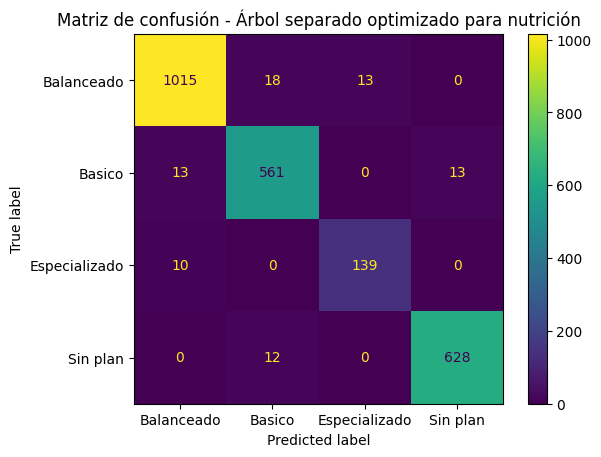

```python
from sklearn.metrics import ConfusionMatrixDisplay, confusion_matrix

labels_nut_opt = ["Balanceado", "Basico", "Especializado", "Sin plan"]
matriz_nut_optimizada = confusion_matrix(
    Y_test_multi["Plan_nutrición"],
    y_pred_nut_optimizado,
    labels=labels_nut_opt,
)

print("Matriz de confusión - Árbol separado optimizado para nutrición\n")
print(matriz_nut_optimizada)

ConfusionMatrixDisplay.from_predictions(
    Y_test_multi["Plan_nutrición"],
    y_pred_nut_optimizado,
    labels=labels_nut_opt,
    display_labels=labels_nut_opt,
)
plt.title("Matriz de confusión - Árbol separado optimizado para nutrición")
plt.show()
```

### Análisis de la matriz de confusión del árbol separado optimizado para nutrición

La matriz de confusión del **árbol separado optimizado para Plan_nutrición** confirma que el modelo tiene un desempeño muy alto y que la mayoría de las observaciones se ubican en la diagonal principal. Esto significa que, en general, el clasificador está asignando correctamente la categoría nutricional real de los usuarios. Los mayores aciertos se observan en **Balanceado** con **1015** casos correctos, **Sin plan** con **628**, **Basico** con **561** y **Especializado** con **139**, lo que refleja una separación bastante clara entre las cuatro clases.

La clase **Basico** también presenta un comportamiento sólido. De los casos reales de esta categoría, **561** fueron clasificados correctamente, mientras que únicamente **13** se confundieron con **Balanceado** y **13** con **Sin plan**. En otras palabras, los errores de esta clase son pocos y están repartidos entre categorías vecinas, no hacia una clase completamente distinta.

Uno de los resultados más importantes es el de **Especializado**, porque era justamente la clase que había mostrado dificultades en el experimento multietiqueta. En esta matriz, el modelo optimizado recupera **139** de **149** casos reales de esa clase y solo comete **10** errores, todos hacia **Balanceado**. Esto muestra una mejora sustancial: el árbol separado ya no ignora esta categoría minoritaria, sino que logra identificarla con un nivel de recall muy alto.

Por último, la clase **Sin plan** también queda muy bien definida, con **628** aciertos y apenas **12** confusiones hacia **Basico**. En conjunto, la matriz respalda la conclusión de que el **árbol separado optimizado** es una mejor alternativa que el enfoque multietiqueta para predecir el plan de nutrición. Los errores son pocos, las confusiones ocurren principalmente entre clases relativamente cercanas y la clase minoritaria **Especializado** queda mucho mejor representada.

```python
import pandas as pd
import numpy as np
from sklearn.compose import ColumnTransformer
from sklearn.impute import SimpleImputer
from sklearn.metrics import confusion_matrix
from sklearn.model_selection import train_test_split
from sklearn.pipeline import Pipeline
from sklearn.preprocessing import OneHotEncoder, StandardScaler
from sklearn.tree import DecisionTreeClassifier

df_diag = pd.read_csv("./data/Datos_Laboratorio3.csv", sep=";", encoding="latin1")
df_diag = df_diag.dropna(subset=["Peso"]).drop(columns=["BMI"])

X_diag = df_diag.drop(columns=["Plan_entrenamiento", "Plan_nutrición"]).copy()
Y_diag = df_diag[["Plan_entrenamiento", "Plan_nutrición"]].copy()

numericas_diag = X_diag.select_dtypes(include=np.number).columns
categoricas_diag = X_diag.select_dtypes(include="object").columns

pipeline_numerico_diag = Pipeline([
    ("imputer", SimpleImputer(strategy="mean")),
    ("scaler", StandardScaler()),
])

pipeline_categorico_diag = Pipeline([
    ("imputer", SimpleImputer(strategy="most_frequent")),
    ("onehot", OneHotEncoder(handle_unknown="ignore")),
])

preprocesador_diag = ColumnTransformer([
    ("num", pipeline_numerico_diag, numericas_diag),
    ("cat", pipeline_categorico_diag, categoricas_diag),
])

X_train_diag, X_test_diag, Y_train_diag, Y_test_diag = train_test_split(
    X_diag,
    Y_diag,
    test_size=0.25,
    random_state=42,
)

pipeline_multietiqueta_diag = Pipeline([
    ("preprocesador", preprocesador_diag),
    (
        "modelo",
        DecisionTreeClassifier(
            criterion="gini",
            splitter="best",
            max_depth=5,
            max_features=None,
            max_leaf_nodes=27,
            random_state=42,
        ),
    ),
])

pipeline_multietiqueta_diag.fit(X_train_diag, Y_train_diag)

Y_pred_diag = pd.DataFrame(
    pipeline_multietiqueta_diag.predict(X_test_diag),
    columns=Y_test_diag.columns,
    index=Y_test_diag.index,
)

print("Distribución real en train - Plan_nutrición")
print(Y_train_diag["Plan_nutrición"].value_counts())

print("\nDistribución real en test - Plan_nutrición")
print(Y_test_diag["Plan_nutrición"].value_counts())

print("\nDistribución predicha por el modelo multietiqueta - Plan_nutrición")
print(Y_pred_diag["Plan_nutrición"].value_counts())

labels_nut = sorted(Y_test_diag["Plan_nutrición"].unique())
print("\nLabels usadas en la matriz:", labels_nut)
print("\nMatriz de confusión - Plan_nutrición")
print(confusion_matrix(
    Y_test_diag["Plan_nutrición"],
    Y_pred_diag["Plan_nutrición"],
    labels=labels_nut,
))
```

```
Distribución real en train - Plan_nutrición
Plan_nutrición
Balanceado       3246
Sin plan         1879
Basico           1698
Especializado     442
Name: count, dtype: int64

Distribución real en test - Plan_nutrición
Plan_nutrición
Balanceado       1046
Sin plan          640
Basico            587
Especializado     149
Name: count, dtype: int64

Distribución predicha por el modelo multietiqueta - Plan_nutrición
Plan_nutrición
Balanceado    1367
Sin plan       825
Basico         230
Name: count, dtype: int64

Labels usadas en la matriz: ['Balanceado', 'Basico', 'Especializado', 'Sin plan']

Matriz de confusión - Plan_nutrición
[[942  46   0  58]
 [256 107   0 224]
 [147   0   0   2]
 [ 22  77   0 541]]
```

# 13. Análisis de resultados

## Análisis de resultados

### ¿Existen variables que podrían ser redundantes o poco informativas?

Sí hay algunas variables que podrían considerarse redundantes o poco informativas. Por ejemplo BMI fue eliminada debido a que se calcula directamente a partir del peso y la altura, lo que genera una alta correlación con estas variables.

Además, en los modelos de árboles de decisión se observó que algunas variables presentan valores de importancia muy bajos, por lo que su contribución a la predicción no es muy util.

### ¿El modelo logra reproducir adecuadamente las recomendaciones presentes en los datos?

Sí los modelos logran dar adecuadamente las recomendaciones presentes en los datos y los modelos de árboles de decisión alcanzaron valores de F1-score de mas de 0.9 para el plan de entrenamiento y mas de 0.83 para el plan de nutrición.

Por lo que podemos decir que el modelo logra capturar los patrones principales utilizados para asignar planes para los usuarios

### A partir de alguno de los modelos creados con árboles de decisión, describa en términos de reglas, las características que cumplen las variables involucradas en la recomendación que se da. Incluya además, la utilidad y la limitación que tienen este estilo de reglas en modelos de árboles de decisión principalmente en el proceso de explicabilidad del modelo.

A partir del árbol de decisión entrenado para el plan de entrenamiento, se pueden interpretar reglas como las siguientes:

- Si el nivel de actividad es alto y el nivel de experiencia es avanzado, entonces es más probable que el usuario reciba un plan de entrenamiento Medio o Alto.
- Si el nivel de experiencia es principiante y el tiempo disponible es bajo, entonces es más probable que se recomiende un plan Bajo o Ninguno.
- Si el objetivo principal es ganancia muscular, el modelo recomendaria planes de entrenamiento mas fuertesl

La principal utilidad de este tipo de reglas es que permiten explicar de manera clara cómo el modelo toma decisiones pero hay limitaciones por ejemplo cuando el árbol crece demasiado, las reglas se vuelven numerosas y difíciles de interpretar completamente, lo que reduce su claridad en niveles mas profundos del modelo

### ¿Cómo podría integrarse este tipo de modelo en una plataforma digital de fitness o bienestar?

Este tipo de modelo podría integrarse en una plataforma digital mediante un sistema automático que solicite al usuario información sobre su perfil físico, hábitos, objetivos personales y demas deatos necesarios, además el sistema podría actualizar las recomendaciones a medida que cambian las características del usuario, permitiendo ofrecer planes adaptados al progreso para ayudar a mejorar la experiencia del usuario y reducir la carga de trabajo de los entrenadores.

### ¿Qué limitaciones tendría utilizar un sistema automático para recomendar planes de entrenamiento?

Una limitación importante es que el modelo depende completamente de la calidad y representatividad de los datos utilizados durante el entrenamiento. Si los datos no incluyen ciertos tipos de usuarios o condiciones específicas, el modelo podría generar recomendaciones poco adecuadas y el sistema automático no reemplaza completamente el criterio de un entrenador con formacion profesional

### ¿Qué fuentes de sesgo podrían estar presentes en los datos o en el proceso de modelado?

Algunas posibles fuentes de sesgo incluyen:

- Sesgo en la recolección de datos: si ciertos grupos de usuarios están subrepresentados, el modelo podría aprender patrones que favorezcan a ciertos perfiles.
- Variables dominantes: variables como el peso o el nivel de actividad podrían influir excesivamente en la decisión, reduciendo la importancia de otras características relevantes.

### 14. Uso de IA en el desarrollo del laboratorio

Durante el desarrollo del laboratorio utilizamos IA generativa como herramienta de apoyo para mejorar la organización del notebook, estructurar las secciones del análisis y verificar la coherencia del flujo de trabajo y ver si nuestros analisis coincidian o podian mejorarse.